# SPARK SQL (CLOUDS Fall 2018)

In this notebook, we will learn how to use the DataFrame API and SparkSQL to perform simple data analytics tasks.

# Goals

The main goals of this notebook are the following:

1. Understand the advantages and disadvantages of using DataFrame over RDD
2. Analyze the airline data with the DataFrame API and SparkSQL

# Steps

- First, in section 1, we will go through a short introduction about the DataFrame API with a small example to see how can we use it and how it compares to the low-level RDD abstraction.
- In section 2, we delve into the details of the use case of this notebook including: providing the context, introducing the data
- In section 3, we perform data exploration and analysis

# 1. RDD and DataFrame APIs

In our previous notebooks, we have worked with RDDs (Resilient Distributed Dataset), the basic abstraction in Spark. The main reason is due to the task at hand: we have been invovled in the design of distributed algorithms.

In this laboratory session, we study (or revisit) the DataFrame API - an immutable distributed collection of data. DataFrames allow developers to impose a **structure** on a distributed collection of data, allowing higher-level abstraction; in addition, DataFrames provide a domain specific language (DSL) API to manipulate distributed, structured data. Ultimately, the goal is to make Spark accessible to a wider audience, beyond researchers and specialized data engineers.

Let's take a small example to see the difference between RDDs and DataFrames. The two cells below contain short code snippets that perform the same task: count the frequency of words in a document, then sort the result in descending order. The first snippet is the same you have been working on in the very [first notebook](https://github.com/EURECOM-CLOUDS-COURSE/Introduction/blob/master/introduction-lab.ipynb) of the CLOUDS course. The second code snippet uses the DataFrame API.

**Question 1.** Run both approaches (RDD and DataFrame) detailed below, compare their runtime, and discuss. Is the DataFrame API approach faster? Can you explain why?

```python
import time
time_start = time.time()
words = (
            # read the text file
            sc.textFile("/datasets/gutenberg/gutenberg_small.txt").repartition(16)

            # construct words from lines
            .flatMap(lambda line: line.split())

            # map each word to (word, 1)
            .map(lambda x: (x, 1))

            # reduce by key: accumulate sum the freq of the same word
            .reduceByKey(lambda freq1, freq2: freq1 + freq2)

            # swap (word, freq) to (freq, word)
            .map(lambda x: (x[1], x[0]))

            # sort result by key DESC
            .sortByKey(False)
         )
print("Runtime: %.2f sec" % (time.time() - time_start))
print(words.take(5))
```

```
Runtime: 133.67 sec
[(29556020, 'the'), (18043957, 'of'), (14914748, 'and'), (12892052, 'to'), (9779124, 'a')]
```

```python
from pyspark.sql.types import *
from pyspark.sql import SQLContext
from pyspark.sql.functions import explode, split, desc
sqlContext = SQLContext(sc)
time_start = time.time()

# read the text file
df = sqlContext.read.text("/datasets/gutenberg/gutenberg_small.txt")

# show 3 samples
# df.show(3)

result = (
    # split into words
    df.select(explode(split(df.value, "\s+|\t+")).alias('aa'))

    # group by each word
    .groupBy(['aa'])

    # count the freq
    .count()

    # sort the result
    .orderBy(desc("count"))
)

result.show(5)
print("Runtime: %.2f sec" % (time.time() - time_start))
```

```
+---+--------+
| aa|   count|
+---+--------+
|the|29556020|
| of|18043957|
|   |16611988|
|and|14914748|
| to|12892052|
+---+--------+
only showing top 5 rows

Runtime: 96.79 sec
```

In above example DataFrame API approach is faster than RDD. The code in DataFrame approach is executed in 96.79, when RDD approach needs 133.67s. It means that RDD almost 40% more time to be executed.

With Spark2.0 release, there are 3 types of data abstractions which Spark officially provides now to use : RDD,DataFrame and DataSet. RDD is the oldest available abstraction. DataFrame has a performance improvement over RDDs because of 2 features:

1. Custom Memory management Data is stored in off-heap memory in binary format. This saves a lot of memory space. Also there is no Garbage Collection overhead involved. By knowing the schema of data in advance and storing efficiently in binary format, expensive java Serialization is also avoided.
2. Optimized Execution Plans  
   Query plans are created for execution using Spark catalyst optimizer. After an optimized execution plan is prepared going through some steps, the final execution happens internally on RDDs only but thats completely hidden from the users.

RDD lets us decide HOW we want to do which limits the optimization Spark can do on processing underneath where as dataframe lets us decide WHAT we want to do and leave everything on Spark to decide how to do computation.

[figure not shown]

# 2. Analysis of flight data using the DataFrame API and SparkSQL

## Use case

In this notebook, we play the role of a data scientist working in the travel industry, specifically on air transportation of passengers. We want to explore the data collected by the Department of Transportation (DoT) to understand passengers' behavior, as well as the properties of all flights, across several airline companies.

The dataset provided by the DoT has 29 features, that can be either categorical or numerical. For example, the `src_airport` (source airport) is categorical: there exist no comparison operator between airport names. We can not say "SGN is bigger than NCE". The `departure_time` feature is numerical, for which a comparison operator exists. For instance, "flight departing before 6PM" can be express by "departure_time < 1800".

In this use case, most features are numerical, except carrier, flight_number, cancelled, cancelation_code and diverted. The data contains a header, that is useless when analyzing the data: it serves the purpose of an "embedded schema", to help data scientist figure out what information is available. Note that there are some features with missing values in some lines of the dataset. The missing values are marked by "NA". These values can cause problems when processing the data and can lead to unexpected results. Therefore, we need to remove the header and replace all "NA" values by empty values, such as they can be interpreted as null values.

## DataFrame

As we have seen already, there are multiple ways to manipulate data:

- Using the RDD abstraction
- Using the DataFrame abstraction.

A DataFrame is a distributed collection of data organized into named columns. It is based on the data frame concept in R language or in Pandas for Python. In some sense, it is similar to a table in a relational database: each item is a list of values (the columns). Also, the value in each row of each column can be accessed by the column's name.

To use DataFrames, the data should be clean (no invalid values). That means we cannot create DataFrame directly from the "RAW" data. Instead, we will first create an RDD from RAW data, produce a new, clean RDD, then transform it to a DataFrame and work on it. The RDD `cleaned_data` is an `RDD[String]`. We need to transform it to `RDD[(TypeOfColumn1, TypeOfColumn2, ..., TypeOfColumn29)]` then call a function to create a DataFrame from the new RDD. Please note that, package `com.databricks.spark.csv` can really help us to load the data efficiently without concerns about parsing, conversions, etc... However, the CSV package can have some problems when loading not well-formatted data or the data that has many kinds of missing values. The guidelines defined this notebook are a general way to help you work with any data.

DataFrames can be constructed from a wide array of sources such as: structured data files, tables in Hive, external databases, or existing RDDs.

During the labs in this course, we will mainly work with CSV data files. So, in the next sections, we only focus on constructing dataframes from structured data files directly and from existing RDD.

### Constructing a DataFrame directly from structured data file

To construct DataFrame from a structured file directly, the file type must be supported. Currently, Spark supports csv, json, avro and many more. Among these types, the csv type is one of the most popular in data analytics. A DataFrame is constructed from csv files by using the package spark-csv from Databricks.

```python
from pyspark.sql import SQLContext
from pyspark.sql.types import *

sqlContext = SQLContext(sc)

df = sqlContext.read.load('/datasets/airline/1994.csv',
    format='com.databricks.spark.csv',
    header='true',
    inferSchema='true',
    nullValue='NA'
)
```

Using the function load parametrized with `com.databricks.spark.csv`, we ask the SqlContext to use the parser from the DataBricks package. Additionally, we can specify whether the file has a header, or ask the parser to guess the data type of columns automatically. The parsed data types is viewed using the function printSchema.

```python
# print(df.dtypes)
df.printSchema()
```

```
root
 |-- Year: integer (nullable = true)
 |-- Month: integer (nullable = true)
 |-- DayofMonth: integer (nullable = true)
 |-- DayOfWeek: integer (nullable = true)
 |-- DepTime: integer (nullable = true)
 |-- CRSDepTime: integer (nullable = true)
 |-- ArrTime: integer (nullable = true)
 |-- CRSArrTime: integer (nullable = true)
 |-- UniqueCarrier: string (nullable = true)
 |-- FlightNum: integer (nullable = true)
 |-- TailNum: string (nullable = true)
 |-- ActualElapsedTime: integer (nullable = true)
 |-- CRSElapsedTime: integer (nullable = true)
 |-- AirTime: string (nullable = true)
 |-- ArrDelay: integer (nullable = true)
 |-- DepDelay: integer (nullable = true)
 |-- Origin: string (nullable = true)
 |-- Dest: string (nullable = true)
 |-- Distance: integer (nullable = true)
 |-- TaxiIn: string (nullable = true)
 |-- TaxiOut: string (nullable = true)
 |-- Cancelled: integer (nullable = true)
 |-- CancellationCode: string (nullable = true)
 |-- Diverted: integer (nullable = true)
 |-- CarrierDelay: string (nullable = true)
 |-- WeatherDelay: string (nullable = true)
 |-- NASDelay: string (nullable = true)
 |-- SecurityDelay: string (nullable = true)
 |-- LateAircraftDelay: string (nullable = true)
```

```python
df = (df
          # change type of column CRSDepTime by casting its values to interger type
          .withColumn('CRSDepTime', df.CRSDepTime.cast('int'))

          # rename the column
          .withColumnRenamed('CRSDepTime', 'scheduled_departure_time')
    )

# print schema of the current data
df.printSchema()

# run jobs to calculate basic statistic information and show it
df.describe().show()
```

```
root
 |-- Year: integer (nullable = true)
 |-- Month: integer (nullable = true)
 |-- DayofMonth: integer (nullable = true)
 |-- DayOfWeek: integer (nullable = true)
 |-- DepTime: integer (nullable = true)
 |-- scheduled_departure_time: integer (nullable = true)
 |-- ArrTime: integer (nullable = true)
 |-- CRSArrTime: integer (nullable = true)
 |-- UniqueCarrier: string (nullable = true)
 |-- FlightNum: integer (nullable = true)
 |-- TailNum: string (nullable = true)
 |-- ActualElapsedTime: integer (nullable = true)
 |-- CRSElapsedTime: integer (nullable = true)
 |-- AirTime: string (nullable = true)
 |-- ArrDelay: integer (nullable = true)
 |-- DepDelay: integer (nullable = true)
 |-- Origin: string (nullable = true)
 |-- Dest: string (nullable = true)
 |-- Distance: integer (nullable = true)
 |-- TaxiIn: string (nullable = true)
 |-- TaxiOut: string (nullable = true)
 |-- Cancelled: integer (nullable = true)
 |-- CancellationCode: string (nullable = true)
 |-- Diverted: integer (nullable = true)
 |-- CarrierDelay: string (nullable = true)
 |-- WeatherDelay: string (nullable = true)
 |-- NASDelay: string (nullable = true)
 |-- SecurityDelay: string (nullable = true)
 |-- LateAircraftDelay: string (nullable = true)

+-------+--------------------+-----------------+------------------+------------------+------------------+------------------------+------------------+-----------------+-------------+-----------------+-------+------------------+------------------+-------+-----------------+------------------+-------+--…
|summary|                Year|            Month|        DayofMonth|         DayOfWeek|           DepTime|scheduled_departure_time|           ArrTime|       CRSArrTime|UniqueCarrier|        FlightNum|TailNum| ActualElapsedTime|    CRSElapsedTime|AirTime|         ArrDelay|          DepDelay| Origin|  …
+-------+--------------------+-----------------+------------------+------------------+------------------+------------------------+------------------+-----------------+-------------+-----------------+-------+------------------+------------------+-------+-----------------+------------------+-------+--…
|  count|             5180048|          5180048|           5180048|           5180048|           5113308|                 5180048|           5101202|          5180048|      5180048|          5180048|      0|           5101202|           5180048|      0|          5101202|           5113308|5180048|51…
|   mean|              1994.0|6.579943853802127|15.723382486031017|3.9516016067804776| 1345.266130849149|      1338.6794068317513|1494.4365151585841|1495.874874904634|         null|920.2637743897354|   null|114.00258860558746|114.82526995888841|   null|5.662489742613603|  6.65992152242736|   null|  …
| stddev|1.747317805780491...|3.436720373974637| 8.788272360339212| 1.990238439719007|470.22426611386146|      463.61750114772104| 483.9849559042809|472.6701494862173|         null|608.1342943927973|   null| 64.88861058427706| 64.20406191593872|   null|23.61815604081688|22.226297708488598|   null|  …
|    min|                1994|                1|                 1|                 1|                 1|                       1|                 1|                1|           AA|                1|   null|               -40|                -5|   null|             -115|              -109|    ABE|  …
|    max|                1994|               12|                31|                 7|              2400|                    2400|              2400|             2400|           WN|             3599|   null|               740|               578|   null|             1313|              1439|    YAK|  …
+-------+--------------------+-----------------+------------------+------------------+------------------+------------------------+------------------+-----------------+-------------+-----------------+-------+------------------+------------------+-------+-----------------+------------------+-------+--…
```

### Constructing a DataFrame from an existing RDD

Another way to construct a DataFrame is using data from an existing RDD. The main advantage of this approach is that it does not need a third party library. However, with this method, we have to remove the header ourself and provide a clear schema.

```python
from pyspark.sql import SQLContext
from pyspark.sql.types import *
from pyspark.sql.functions import explode, split, desc, col, udf, round
%matplotlib inline
import matplotlib.pyplot as plt
import matplotlib.colors as mcolors
import pandas as pd
import numpy as np
import pyspark.sql.functions as func
import matplotlib.patches as mpatches
import seaborn as sns

sqlContext = SQLContext(sc)

data = sc.textFile('/datasets/airline/1994.csv')

# extract the header
header = data.first()

# replace invalid data with NULL and remove header
cleaned_data = (
        data

        # filter out the header
        .filter(lambda line: line != header)

         # replace the 'missing data' by empty value
        .map(lambda line: ','.join(list(map(lambda x: x if x != 'NA' else '',line.split(',')))))
    )

airline_data_schema = StructType([ \
    #StructField( name, dataType, nullable)
    StructField("year",                     IntegerType(), True), \
    StructField("month",                    IntegerType(), True), \
    StructField("day_of_month",             IntegerType(), True), \
    StructField("day_of_week",              IntegerType(), True), \
    StructField("departure_time",           IntegerType(), True), \
    StructField("scheduled_departure_time", IntegerType(), True), \
    StructField("arrival_time",             IntegerType(), True), \
    StructField("scheduled_arrival_time",   IntegerType(), True), \
    StructField("carrier",                  StringType(),  True), \
    StructField("flight_number",            StringType(),  True), \
    StructField("tail_number",              StringType(),  True), \
    StructField("actual_elapsed_time",      IntegerType(), True), \
    StructField("scheduled_elapsed_time",   IntegerType(), True), \
    StructField("air_time",                 IntegerType(), True), \
    StructField("arrival_delay",            IntegerType(), True), \
    StructField("departure_delay",          IntegerType(), True), \
    StructField("src_airport",              StringType(),  True), \
    StructField("dest_airport",             StringType(),  True), \
    StructField("distance",                 IntegerType(), True), \
    StructField("taxi_in_time",             IntegerType(), True), \
    StructField("taxi_out_time",            IntegerType(), True), \
    StructField("cancelled",                StringType(),  True), \
    StructField("cancellation_code",        StringType(),  True), \
    StructField("diverted",                 StringType(),  True), \
    StructField("carrier_delay",            IntegerType(), True), \
    StructField("weather_delay",            IntegerType(), True), \
    StructField("nas_delay",                IntegerType(), True), \
    StructField("security_delay",           IntegerType(), True), \
    StructField("late_aircraft_delay",      IntegerType(), True)\
])
```

```python
# convert each line into a tuple of features (columns) with the corresponding data type
cleaned_data_to_columns = (
    cleaned_data.map(lambda l: l.split(","))
    .map(lambda cols:
         (
            int(cols[0])  if cols[ 0] else None,
            int(cols[1])  if cols[ 1] else None,
            int(cols[2])  if cols[ 2] else None,
            int(cols[3])  if cols[ 3] else None,
            int(cols[4])  if cols[ 4] else None,
            int(cols[5])  if cols[ 5] else None,
            int(cols[6])  if cols[ 6] else None,
            int(cols[7])  if cols[ 7] else None,
            cols[8]       if cols[ 8] else None,
            cols[9]       if cols[ 9] else None,
            cols[10]      if cols[10] else None,
            int(cols[11]) if cols[11] else None,
            int(cols[12]) if cols[12] else None,
            int(cols[13]) if cols[13] else None,
            int(cols[14]) if cols[14] else None,
            int(cols[15]) if cols[15] else None,
            cols[16]      if cols[16] else None,
            cols[17]      if cols[17] else None,
            int(cols[18]) if cols[18] else None,
            int(cols[19]) if cols[19] else None,
            int(cols[20]) if cols[20] else None,
            cols[21]      if cols[21] else None,
            cols[22]      if cols[22] else None,
            cols[23]      if cols[23] else None,
            int(cols[24]) if cols[24] else None,
            int(cols[25]) if cols[25] else None,
            int(cols[26]) if cols[26] else None,
            int(cols[27]) if cols[27] else None,
            int(cols[28]) if cols[28] else None
         ))
)

# create dataframe
df = sqlContext.createDataFrame(cleaned_data_to_columns, airline_data_schema)\
    .select(['year', 'month', 'day_of_month', 'day_of_week',
            'scheduled_departure_time','scheduled_arrival_time',
            'arrival_delay', 'distance',
            'src_airport', 'dest_airport', 'carrier'])\
    .cache()
```

### Examples

Using the contructed DataFrame, we can answer some simple questions:

- How many night flights do we have in our data?
- How many night flights per unique carrier?

**NOTE:** We define "night" to start at 6pm.

```python
df[df.scheduled_departure_time > 1800].count()
```

```
1078203
```

```python
df[df.scheduled_departure_time > 1800].groupBy(df.carrier).count().orderBy('count', ascending=0).collect()
```

```
[Row(carrier='DL', count=208224),
 Row(carrier='US', count=170397),
 Row(carrier='AA', count=142832),
 Row(carrier='WN', count=124024),
 Row(carrier='UA', count=113640),
 Row(carrier='NW', count=100453),
 Row(carrier='CO', count=94501),
 Row(carrier='TW', count=54771),
 Row(carrier='HP', count=44351),
 Row(carrier='AS', count=25010)]
```

# 3. Data exploration

Next, we will go over a series of simple queries on our data, to perform exploration and compute statistics using the DataFrame API and SparkSQL. These queries directly map to the questions you need to answer.

**NOTE:** finding the right question to ask is difficult! Don't be afraid to complement the questions below, with your own questions that, in your opinion, are valuable ways to inspect data. This can give you extra points!

- Basic queries:
  - How many unique origin airports?
  - How many unique destination airports?
  - How many carriers?
  - How many flights that have a scheduled departure time later than 18h00?
- Statistics on flight volume: this kind of statistics are helpful to reason about delays. Indeed, it is plausible to assume that "*the more flights in an airport, the higher the probability of delay*".
  - How many flights in each month of the year?
  - Is there any relationship between the number of flights and the days of week?
  - How many flights in different days of months and in different hours of days?
  - Which are the top 20 busiest airports (this depends on inbound and outbound traffic)?
  - Which are the top 20 busiest carriers?
- Statistics on the fraction of delayed flights
  - What is the percentage of delayed flights (over total flights) for different hours of the day?
  - Which hours of the day are characterized by the longest flight delay?
  - What are the fluctuation of the percentage of delayed flights over different time granularities?
  - What is the percentage of delayed flights which depart from one of the top 20 busiest airports?
  - What is the percentage of delayed flights which belong to one of the top 20 busiest carriers?

## Question 2: Basic queries

### Question 2.1

How many origin airports? How many destination airports? Discuss the results, indicating any discrepancies or strange facts about the data.

```python
# Number of origin airports
origin_airport = df.select('src_airport').distinct().count()
print("Number of origin airports:", origin_airport)

# Number of destination airports
destination_airport = df.select('dest_airport').distinct().count()
print("Number of destination airports:", destination_airport)
```

```
Number of origin airports: 224
Number of destination airports: 225
```

Number of origin airports is lower (by 1) that number of destination airports. It's something which needs to be investigated further. Firstly we need to check which airport is not present in the origing airport data.

```python
print('Names of origin airports which are not presented in destination airports data:')
df.select('src_airport').subtract(df.select('dest_airport')).show()
print('Names of destination airports which are not presented in origin airports data:')
df.select('dest_airport').subtract(df.select('src_airport')).show()
```

```
Names of origin airports which are not presented in destination airports data:
+-----------+
|src_airport|
+-----------+
|        SPN|
+-----------+

Names of destination airports which are not presented in origin airports data:
+------------+
|dest_airport|
+------------+
|         BFI|
|         GUM|
+------------+
```

Now we see that there is 1 origin airport which is not present in dataset as destination airports, and 2 destination airports which are not present in dataset as origin airports. This is suspicious as usually we are expecting that the same plane which land on the airport will leave this airport and as so we should have the same destination and origin airport. To investigate it further we will have checked when there were flights (from/to) these airports and which carrier was operating.

```python
print('Flights from SPN airport:')
source_airport = df.select('src_airport','month','day_of_month','carrier','dest_airport').where(df.src_airport=='SPN')
source_airport.show()
print('Flights to SPN and BFI airports:')
destination_airport= df.select('dest_airport','month','day_of_month','Carrier').where(df.dest_airport.isin('BFI','GUM'))
destination_airport.show()
```

```
Flights from SPN airport:
+-----------+-----+------------+-------+------------+
|src_airport|month|day_of_month|carrier|dest_airport|
+-----------+-----+------------+-------+------------+
|        SPN|   12|           4|     UA|         GUM|
|        SPN|   12|           7|     UA|         GUM|
|        SPN|   12|          11|     UA|         GUM|
|        SPN|   12|          14|     UA|         GUM|
|        SPN|   12|          21|     UA|         GUM|
|        SPN|   12|          25|     UA|         GUM|
|        SPN|   12|          28|     UA|         GUM|
+-----------+-----+------------+-------+------------+

Flights to SPN and BFI airports:
+------------+-----+------------+-------+
|dest_airport|month|day_of_month|Carrier|
+------------+-----+------------+-------+
|         BFI|    8|          26|     AS|
|         GUM|   12|           4|     UA|
|         GUM|   12|           7|     UA|
|         GUM|   12|          11|     UA|
|         GUM|   12|          14|     UA|
|         GUM|   12|          21|     UA|
|         GUM|   12|          25|     UA|
|         GUM|   12|          28|     UA|
+------------+-----+------------+-------+
```

### Question 2.2

How many unique carriers are present in the data?

```python
# Number of unique carriers
unique_carriers = df.select('carrier').distinct().count()
print("Number of unique carriers:", unique_carriers)
```

```
Number of unique carriers: 10
```

### Question 2.3

- How many night flights (that is, flights departing later than 6pm or earlier than 6am)?
- What is the percentage of night flights over the total volume of flights

**NOTE:** Here we're using a more refined definition of what is a night flight, than in our earlier examples.

```python
# Number ofnight flights
number_of_night_flights = (df[~df.scheduled_departure_time.between(600,1800)].count())
print('Number of night flights:', number_of_night_flights)

# Percentage of night flights over the total volume of flights
percentage = number_of_night_flights/df.count()*100
print('Percentage of night flights over the total volume of flights:', percentage,'%')
```

```
Number of night flights: 1121918
Percentage of night flights over the total volume of flights: 21.658447952605844 %
```

## Question 3: Flight volume statistics

### Question 3.1:

How many flights in each month of the year? Plot the changes over months by a line chart and comment the figure.  
From the result, we can learn the dynamics of flight volume over months. For example, if we only consider flights in 1994 (to start, it's always better to focus on smaller amount of data), we can discuss about which months are most likely to have flights experiencing delays.

```
Number of flights per month:
+-----+------+
|month| count|
+-----+------+
|    1|423861|
|    2|386954|
|    3|435516|
|    4|420995|
|    5|436432|
|    6|426490|
|    7|443736|
|    8|451086|
|    9|430861|
|   10|449369|
|   11|428227|
|   12|446521|
+-----+------+
```

```
Text(0.5,1,"Monthly flight's volume in 1994")
```

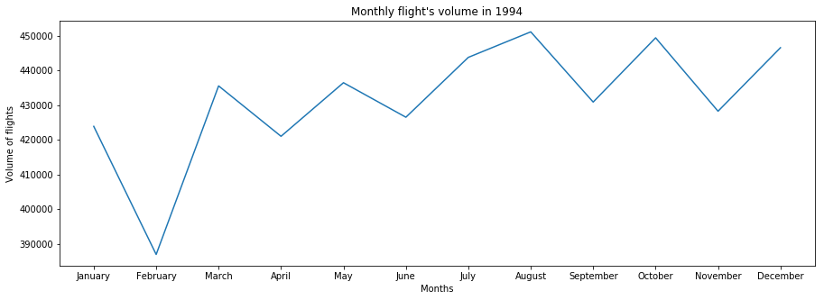

```python
#Firstly we checked how many years are covered in our data:
#df.groupBy(df.year).count().orderBy('count', ascending=0).show()
#As there is only 1994 we don't need to do analyze per year.

#For plot purpose we create names of the months list
months_names=['January', 'February', 'March', 'April', 'May', 'June', 'July', 'August', 'September', 'October', 'November', 'December']

#Calulation of number of flight per month
monthly_flights= df.groupBy(df.month).count().orderBy('month', ascending=1)
#Print top 20 results
print('Number of flights per month:')
monthly_flights.show()

#Plot
months=[x for x in range(12)]
volume=[x[1] for x in monthly_flights.collect()]

plt.figure(0)
plt.figure(figsize=(15,5))
plt.plot(months, volume)
plt.xticks([x for x in range(12)], months_names)
plt.xlabel("Months")
plt.ylabel("Volume of flights")
plt.title("Monthly flight's volume in 1994")
```

Number of flights is changing monthly. The lowest number of flight is in February and the highest in August - so during the holidays.  
We might be tempted to make a conclusion that seasonality pattern appears every month and after a month with growing volume we should expect decreasing volume in next month (and vice versa). But if we say that 'People travel more often in May that in June', we will be mistaken. We need to take into consideration the numbers of days in the month. We will perform analyze with average number of flights per day per month below.

```
Text(0.5,1,'Average number of flights per day in different months')
```

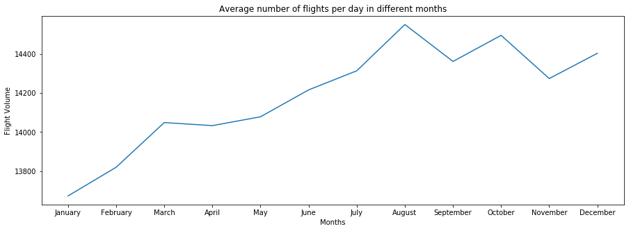

```python
#Calulation of average number of flights per day in different months
day_of_months_flights2 = df.groupBy(df.month, df.day_of_month).count().orderBy(df.month, df.day_of_month)

values_list = []
for month in range(1,13):
    day_in_month =day_of_months_flights2[df.month==month].count()
    avarage_monthly_flights= df[df.month==month].count()/day_in_month
    values_list.append(avarage_monthly_flights)

#Plot
months=[x for x in range(12)]
volume=[x for x in values_list]

plt.figure(0)
plt.figure(figsize=(15,5))
plt.plot(months, volume)
plt.xticks([x for x in range(12)], months_names)
plt.xlabel("Months")
plt.ylabel("Flight Volume")
plt.title("Average number of flights per day in different months")
```

When we calculate average number of flights per day, we can see that in June there are more flights per day that in May.  
To see the yearly pattern, we would need data from more years. From the above picture we can assume that there is a growing trend of number of flight per years. So we would expect the number of flights in January 1995 will be higher than in January 1994 and maybe closer to December 1994 and number of flights will be growing through the year 1995. This would make sense, however it is also possible that this is how yearly pattern looks like (that always in January we can expect less flights and that number of flight grows within a year to drop again in January). Of course knowing how the flight industry looks like we are more convinced that there is a growing trend in flight industry (so first interpretation is more correct).  
It's worth to notice that no matter if there is a growing trend in flight industry, or we have monthly discrepancy - there is a pick of flights in holiday season.

To conclude: If we would like to predict what should be the flight volume in next year, we would like to have data from more years (at least 2 years). Then we can analyze correctly if we have monthly seasonality and we could extract trend. I think that the best approach would be to predict basing on average number of flights per month rather that monthly flight volume. In first for sure we would need to deal with monthly seasonality and extract seasonality and trend. Furthermore, we might have not higher error in February for the leap year.

### Question 3.2:

Is there any relationship between the number of flights and the days of the week? Plot a bar chart and interpret the figure.  
**NOTE:** You should study both global aggregates (irrespectively of the month of the year), and monthly aggregates (day statistics, for each different month of the year).  
By answering this question, we could learn about the importance of the weekend/weekday feature for our predictive task.

```
Yearly number of flights in different days of the week:
+-----------+------+
|day_of_week| count|
+-----------+------+
|          1|754636|
|          2|756532|
|          3|756864|
|          4|751537|
|          5|751531|
|          6|695245|
|          7|713703|
+-----------+------+

Montly view of numbers of flights volume in different days of the week:
+-----+-----------+-----+
|month|day_of_week|count|
+-----+-----------+-----+
|    1|          1|70761|
|    1|          2|56327|
|    1|          3|55944|
|    1|          4|55870|
|    1|          5|56041|
|    1|          6|62488|
|    1|          7|66430|
|    2|          1|56645|
|    2|          2|56549|
|    2|          3|56460|
|    2|          4|56421|
|    2|          5|56823|
|    2|          6|50611|
|    2|          7|53445|
|    3|          1|57356|
|    3|          2|71424|
|    3|          3|71900|
|    3|          4|71942|
|    3|          5|57400|
|    3|          6|51347|
+-----+-----------+-----+
only showing top 20 rows
```

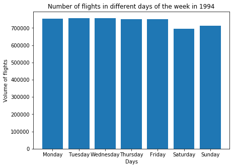

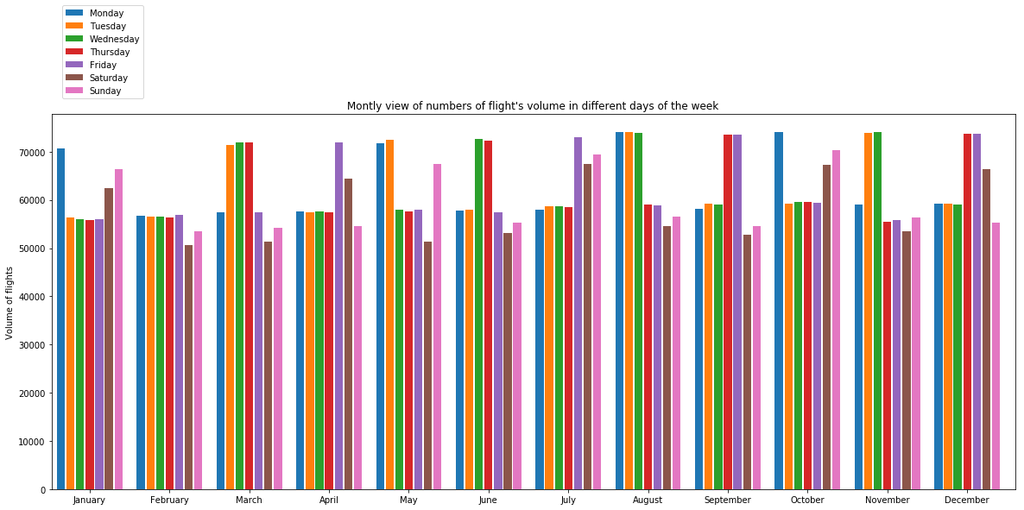

```python
import matplotlib.pyplot as plt

#For plot purpose we create names of days list
days_name = ['Monday', 'Tuesday', 'Wednesday', 'Thursday', 'Friday', 'Saturday', 'Sunday']

### GLOBAL AGGREGATES
#Calulation of dayly flight volume
day_of_week_flights= df.groupBy(df.day_of_week).count().orderBy('day_of_week', ascending=1)

#Print top 20 results
print('Yearly number of flights in different days of the week:')
day_of_week_flights.show()

#Plot
days=[x for x in range(1,8)]
volume2=[x[1] for x in day_of_week_flights.collect()]

plt.figure(0)
plt.figure(figsize=(7,5))
plt.bar(days, volume2)
plt.xticks([x for x in range(1,8)],days_name)
plt.xlabel("Days")
plt.ylabel("Volume of flights")
plt.title("Number of flights in different days of the week in 1994")

### MONTHLY AGGREGATES
#Calulation of dayly flight volume
day_of_week_flights2 = df.groupBy(df.month, df.day_of_week).count().orderBy(df.month, df.day_of_week)

#Print top 20 results
print('Montly view of numbers of flights volume in different days of the week:')
day_of_week_flights2.show()

#Collect results
day_of_week_flights2 = day_of_week_flights2.collect()

#Plot
dim = list(range(12))
w = 0.12

fig, ax = plt.subplots(figsize=(20,8))

# range of 12 as we have 12 months, range of 7 as we have 7 days
for days in range(7):
    values_list = []
    for month in range(12):
        values_list.append(day_of_week_flights2[month*7+days][2])
    plt.bar([x + w*days for x in dim], values_list, w-0.02)

ax.set_ylabel('Volume of flights')
ax.set_title("Montly view of numbers of flight's volume in different days of the week")
ax.set_xticks([x + 3 * w for x in dim])
ax.set_xticklabels(months_names)
plt.xlim(min(dim)-w, max(dim)+w*(7+1))
plt.legend(days_name , loc='best', bbox_to_anchor=(-0.4, 0.8, 0.5, 0.5))
plt.show()
```

Firstly, we checked with calendar for 1994 that day 1 stands for Monday. It was not so obvious as sometimes Sunday is treated as a first day in databases. From the first figure it seems that on weekends there are less flights that during the weekdays. From monthly view we've noticed that in order to see the pattern we need to decide how many week days we have in the month. For example, it seems that in January there are more flights on Monday. However, it's not true as it's hard to compare volume of 5 Mondays with regards to 4 Tuesdays in Month.

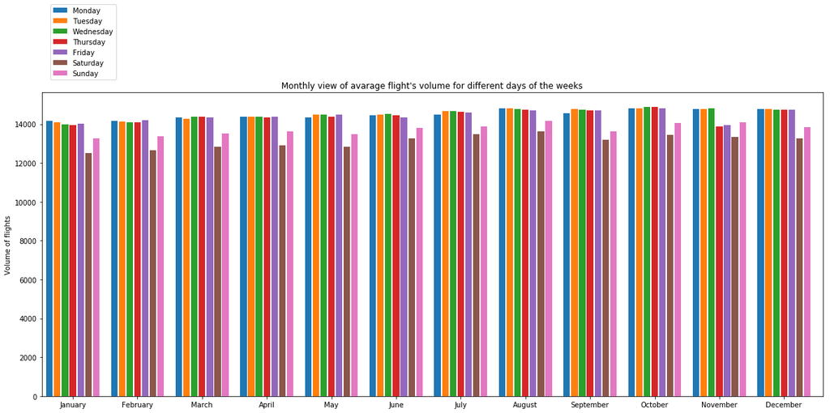

```python
#Plot and calculation of monthly view of avarage flight's volume for different days of the weeks

dim = list(range(12))
w = 0.12

fig, ax = plt.subplots(figsize=(20,8))

for days in range(7):
    values_list = []
    for month in range(12):
        #Counting avarage flight's volume for different days of the weeks (in monthly view)
        count = df.select('month','day_of_week','day_of_month').where(df.month==month+1).distinct().groupBy('day_of_week').count().select('count').where(df.day_of_week==days+1).collect()[0][0]
        values_list.append(day_of_week_flights2[month*7+days][2]/count)
    plt.bar([x + w*days for x in dim], values_list, w-0.02)

ax.set_ylabel('Volume of flights')
ax.set_title("Monthly view of avarage flight's volume for different days of the weeks")
ax.set_xticks([x + 3 * w for x in dim])
ax.set_xticklabels(months_names)
plt.xlim(min(dim)-w, max(dim)+w*(7+1))
plt.legend(days_name , loc='best', bbox_to_anchor=(-0.4, 0.8, 0.5, 0.5))
plt.show()
```

### Question 3.3

How many flights in different days of months and in different hours of days?  
**NOTE:** Similarly to the previous note, you need to compute both global statistcs and monthly statistics.  
Plot bar charts, and interpret your figures.

```
Daily flight's volume
+------------+------+
|day_of_month| count|
+------------+------+
|           1|169674|
|           2|169829|
|           3|168678|
|           4|169399|
|           5|168423|
|           6|170650|
|           7|172210|
|           8|170674|
|           9|170077|
|          10|170252|
|          11|172362|
|          12|169542|
|          13|171230|
|          14|172081|
|          15|170737|
|          16|169985|
|          17|170132|
|          18|171868|
|          19|169483|
|          20|171142|
+------------+------+
only showing top 20 rows
```

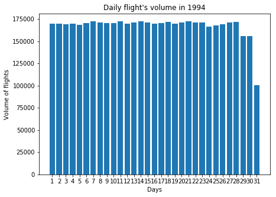

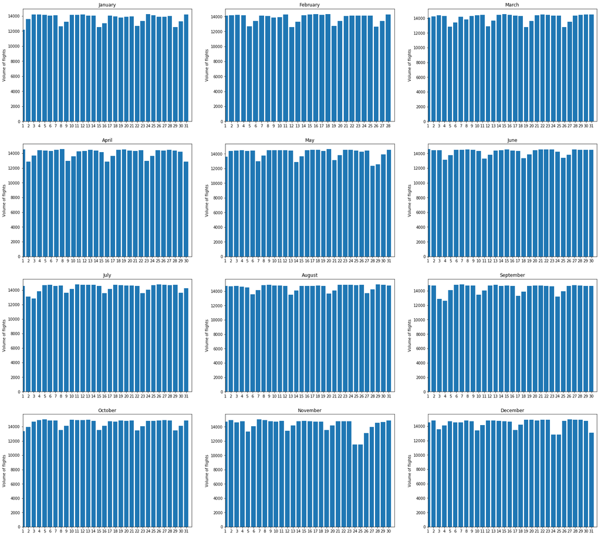

```python
### GLOBAL AGGREGATES
#Calculation
day_of_month_flights= df.groupBy(df.day_of_month).count().orderBy('day_of_month', ascending=1)
#Print top 20 results
print("Daily flight's volume")
day_of_month_flights.show()

#Plot
month_days=[x for x in range(1,32)]
volume=[x[1] for x in day_of_month_flights.collect()]

plt.figure(0)
plt.figure(figsize=(7,5))
plt.bar(month_days, volume)
plt.xticks([x for x in range(1,32)],month_days)
plt.xlabel("Days")
plt.ylabel("Volume of flights")
plt.title("Daily flight's volume in 1994")

### MONTHLY AGGREGATES
#Calculation
day_of_month_flights2= df.groupBy(df.month, df.day_of_month).count().orderBy(df.month, df.day_of_month)

# Plot
plt.figure(figsize=(27, 25))
a = 4
b = 3
for i in range(12):
    monthly_flights = day_of_month_flights2[df.month == i+1].select('count').collect()
    plt.subplot(a, b, i+1)
    plt.bar([x for x in range(len(monthly_flights))], [x[0] for x in monthly_flights])
    plt.ylabel('Volume of flights')
    plt.title(months_names[i])
    plt.xticks([p for p in range(len(monthly_flights))], [p+1 for p in range(len(monthly_flights))])
    plt.xlim(0, len(monthly_flights))
plt.show()
```

From the yearly view figure we see that there are less flights on 29-31 day of the month. On 31 it's caused by this that not every month has 31 days, and drop in 29-30 is caused by this that February has only 28 days.

On the monthly view we can observe day of the week seasonality (weekends are less popular). Additionally, there few discrepancies from the pattern which are caused by the public holidays:

- May 28-30 - there is a pick down related to the Memorial Day (May 30th)
- July 1-4 - there is a pick down related to the Independence Day (July 4th)
- September 3-5 - there is a pick down related to Labor Day (Sep 5th)
- November 24-26 - there is a pick down related to Thanksgiving and Black Friday
- December 24-25 - there is a pick down related to Christmas

```
Hourly flight's volume
+----------------+------+
|flight_full_hour| count|
+----------------+------+
|               0| 13642|
|               1| 12825|
|               2|  2842|
|               3|   564|
|               4|   486|
|               5| 13357|
|               6|257486|
|               7|398796|
|               8|397060|
|               9|341597|
|              10|300375|
|              11|313577|
|              12|356830|
|              13|360762|
|              14|294214|
|              15|313131|
|              16|317809|
|              17|368695|
|              18|338147|
|              19|287033|
|              20|232898|
|              21|168138|
|              22| 52395|
|              23| 37389|
+----------------+------+
```

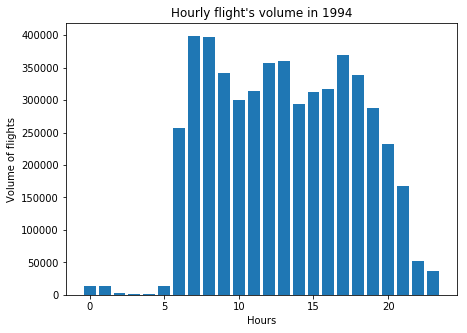

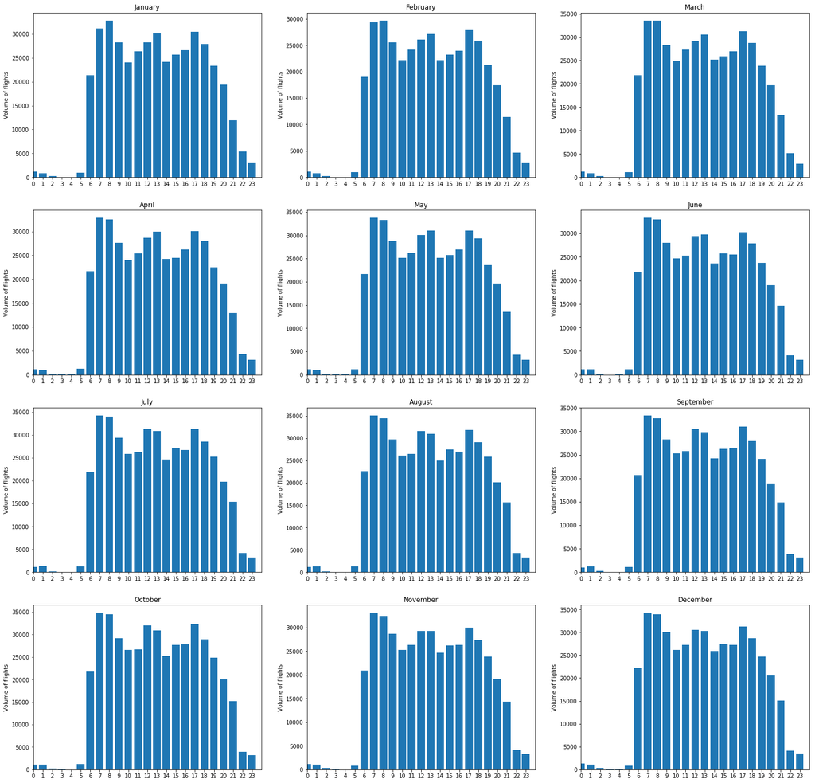

```python
from pyspark.sql.functions import floor
### GLOBAL AGGREGATES

#Calculation
df_flight_full_hour = df.withColumn('flight_full_hour', floor(df.scheduled_departure_time/100)%24)
flight_hour = df_flight_full_hour.groupBy('flight_full_hour').count().orderBy('flight_full_hour',ascending=1)

#Print top 20 results
print("Hourly flight's volume")
flight_hour.show(24)

#Plot
hours=[x for x in range(0,24)]
volume=[x[1] for x in flight_hour.collect()]
plt.figure(0)
plt.figure(figsize=(7,5))
plt.bar(hours, volume)
#plt.xticks([x for x in range(1,32)],month_days)
plt.xlabel("Hours")
plt.ylabel("Volume of flights")
plt.title("Hourly flight's volume in 1994")

### MONTHLY AGGREGATES
#Calculate
flight_hour2 = df_flight_full_hour.groupBy('month', 'flight_full_hour').count().orderBy('month','flight_full_hour')

#Plot
plt.figure(figsize=(25, 25))
a = 4
b = 3
for i in range(12):
    monthly_flights = flight_hour2[df.month == i+1].select('count').collect()
    plt.subplot(a, b, i+1)
    plt.bar([x for x in range(len(monthly_flights))], [x[0] for x in monthly_flights])
    plt.ylabel('Volume of flights')
    plt.title(months_names[i])
    plt.xticks([p for p in range(len(monthly_flights))], [p for p in range(len(monthly_flights))])
    plt.xlim(0, len(monthly_flights))
plt.show()
```

There is a pattern in the hourly volume of flights. The pattern is the same for each month.  
Flights starting between 22 and midnight are not very popular and after the midnight till 6 am there starts to be even less popular as there is a very small portion of the flights. Flights starts to be roughly grow up starting from 6 am. Then at 7 am there is a pick up which starts to drop down till 10 am. After 10 am number of flights are growing again till 12-13 (where we have another pick). Then number of flights drop a 2 pm and have another pick 5 pm. From 5 pm number of flights starts to drop down.  
The highest volume is at 7 in most cases or at 8 in January and in February.

### Question 3.4

Which are the **top 20** busiest airports? Compute this in terms of the inbound, outbound and total number of flights.

```python
# Top 20 airports in inbound flights
print("Top 20 airports in inbound flights:")
top20_inbound= df.groupBy(df.dest_airport).count().alias('count1').orderBy('count', ascending=0)
top20_inbound = top20_inbound.withColumn('ratio', func.round(top20_inbound[1]/top20_inbound.groupBy().sum().collect()[0][0],3))
top20_inbound.show()

# Top 20 airports in outbound flights
print("Top 20 airports in outbound flights:")
top20_outbound= df.groupBy(df.src_airport).count().orderBy('count', ascending=0)
top20_outbound = top20_outbound.withColumn('ratio', func.round(top20_outbound[1]/top20_outbound.groupBy().sum().collect()[0][0],3))
top20_outbound.show()

# Top 20 airports in total number of flights
print("Top 20 airports in total number of flights:")
df_total = df.withColumn('airport', df.src_airport).union(df.withColumn('airport', df.dest_airport))
top20_total = df_total.groupBy('airport').count().orderBy('count', ascending=False)
top20_total = top20_total.withColumn('ratio', func.round(top20_total[1]/top20_total.groupBy().sum().collect()[0][0],3))
top20_total.show()

x= sum(top20_total.take(20)[i][2] for i in range(20))
print('20 top airport are resposible for' ,x,'% of total traffic')
```

```
Top 20 airports in inbound flights:
+------------+------+-----+
|dest_airport| count|ratio|
+------------+------+-----+
|         ORD|283720|0.055|
|         DFW|260249| 0.05|
|         ATL|221588|0.043|
|         LAX|152959| 0.03|
|         STL|152800|0.029|
|         DEN|144099|0.028|
|         PHX|140979|0.027|
|         DTW|139435|0.027|
|         PIT|131962|0.025|
|         CLT|130321|0.025|
|         MSP|124758|0.024|
|         SFO|117245|0.023|
|         EWR|117223|0.023|
|         IAH|104409| 0.02|
|         LGA|101498| 0.02|
|         BOS| 99331|0.019|
|         LAS| 94948|0.018|
|         PHL| 93312|0.018|
|         DCA| 87670|0.017|
|         MCO| 76600|0.015|
+------------+------+-----+
only showing top 20 rows

Top 20 airports in outbound flights:
+-----------+------+-----+
|src_airport| count|ratio|
+-----------+------+-----+
|        ORD|277741|0.054|
|        DFW|256274|0.049|
|        ATL|221486|0.043|
|        LAX|153494| 0.03|
|        STL|151609|0.029|
|        DEN|141427|0.027|
|        PHX|139581|0.027|
|        DTW|136837|0.026|
|        PIT|130977|0.025|
```

[output cut: 27 more lines]

```
|    CLT|259712|0.025|
|    MSP|247980|0.024|
|    SFO|235478|0.023|
|    EWR|233991|0.023|
|    IAH|208591| 0.02|
|    LGA|203362| 0.02|
|    BOS|199696|0.019|
|    LAS|189920|0.018|
|    PHL|186897|0.018|
|    DCA|176115|0.017|
|    MCO|153720|0.015|
+-------+------+-----+
only showing top 20 rows

20 top airport are resposible for 0.5350000000000003 % of total traffic
```

There is no surprise that the same airport which has the highest number of inbound flights, have also the highest number of outbound flights and number of total flights. On this representation of top 20 airports we have noticed discrepancies between the number of inbound flights, and outbound flights. This percentage discrepancies aren't huge and are probably caused by the end/beginning of the year travels.  
The biggest airport is responsible for 5% of all trafic,and the 20th airport for 1.5%. 20 top airport are resposible for around 50% of total traffic.

### Question 3.5

Which are the **top 20** busiest carriers? Compute this in terms of number of flights.

```python
# Top 20 busiest carriers
print("Top 20 busiest carriers:")
top20_carriers =  df.groupBy(df.carrier).count().orderBy('count', ascending=0)
top20_carriers.show()
```

```
Top 20 busiest carriers:
+-------+------+
|carrier| count|
+-------+------+
|     DL|874526|
|     US|857906|
|     AA|722277|
|     UA|638750|
|     WN|565426|
|     CO|484834|
|     NW|482798|
|     TW|258205|
|     HP|177851|
|     AS|117475|
+-------+------+
```

There are only 10 carriers presented in our data so analyses of top 20 means the same as analyses of top 10 and in fact analyses all carriers. ,br>

## Question 4

In this series of questions we focus on the computation of statistics about the percentage of delayed flights.

### Question 4.1

What is the percentage of delayed flights for different hours of the day? Plot a bar chart and interpret the figure.

IMPORTANT!

A flight is considered as delayed if it's actual arrival time is more than 15 minutes later than the scheduled arrival time.

```
Percentage of delayed flights depending on hour of departure
+----------------+------------------+
|flight_full_hour|       delay_ratio|
+----------------+------------------+
|               0| 17.09426770268289|
|               1|14.838206627680313|
|               2| 5.348346235045742|
|               3|1.5957446808510638|
|               4|   5.1440329218107|
|               5| 6.094182825484765|
|               6| 8.068399835330853|
|               7|10.564549293373053|
|               8|13.353901173626152|
|               9| 14.67870033987418|
|              10|13.552392842280483|
|              11|14.784247569177586|
|              12|15.775859653056077|
|              13|16.822448040536422|
|              14|17.263964325287034|
|              15| 19.96640383737158|
|              16|20.660837169494886|
|              17|22.946880212641886|
|              18|22.302134870337458|
|              19|23.267011110220775|
|              20|21.309328547261032|
|              21|20.222674231880955|
|              22|  19.5667525527245|
|              23|17.093262724330685|
+----------------+------------------+
```

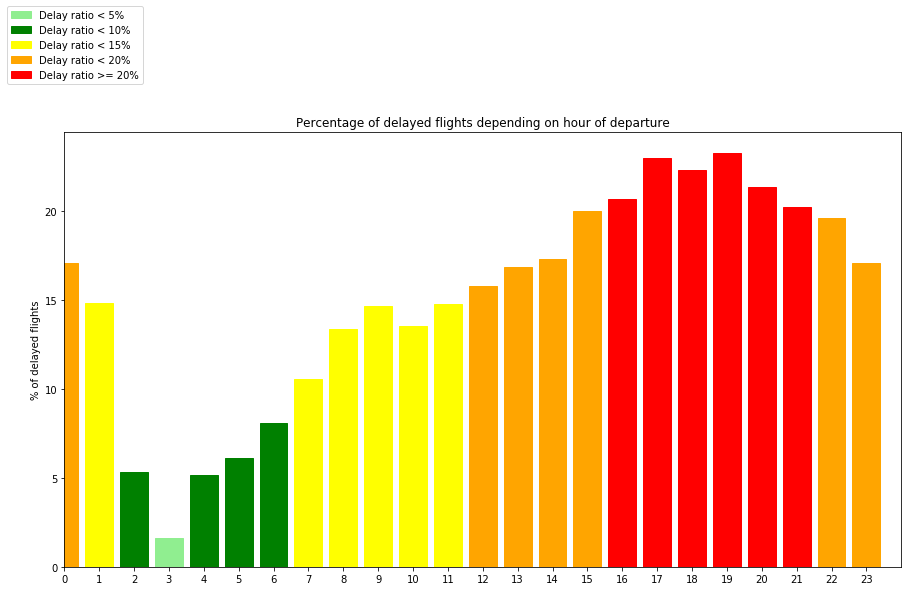

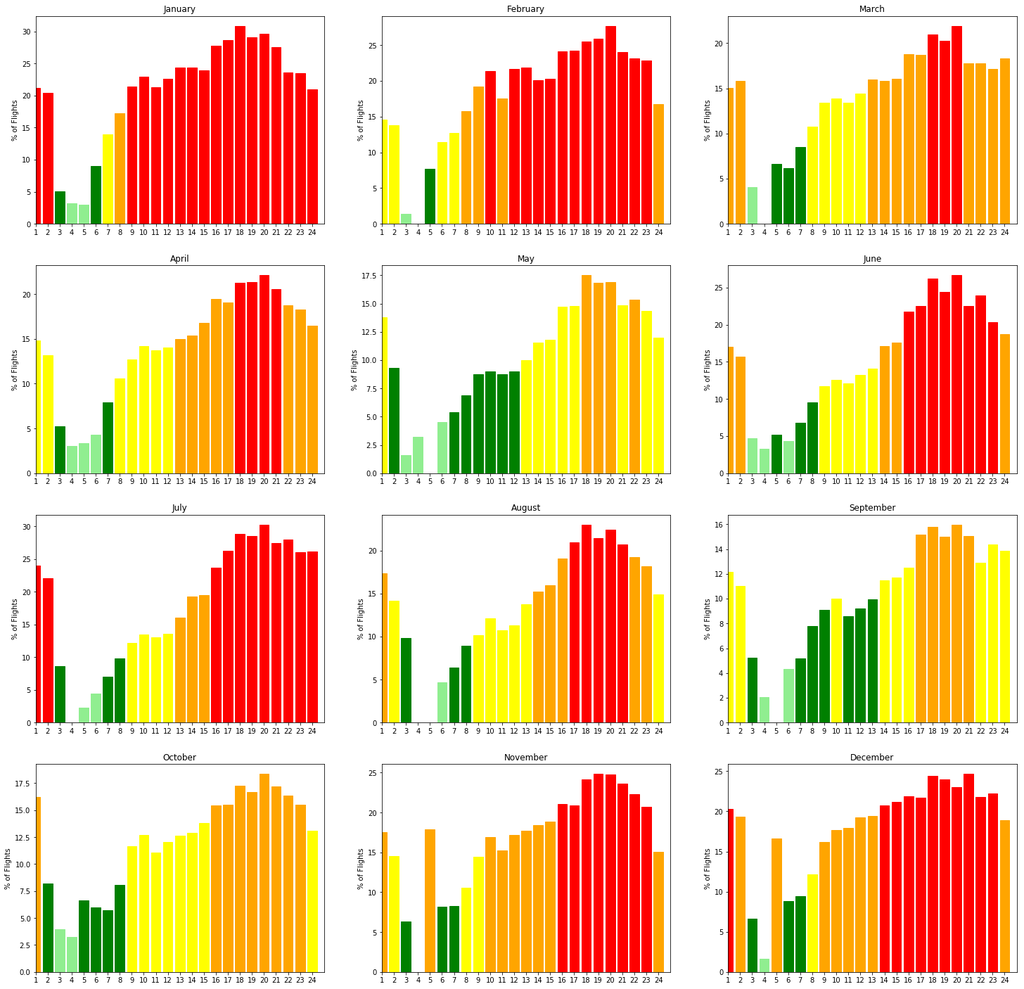

```python
from pyspark.sql.functions import floor
### GLOBAL AGGREGATES
# Calculate
df_is_delayed = df_flight_full_hour.withColumn('is_delayed', func.when(df_flight_full_hour.arrival_delay>=15,1).otherwise(0))
statistics = df_is_delayed.groupBy('flight_full_hour').agg((100*func.sum('is_delayed')/func.count('*')).alias('delay_ratio')).orderBy('flight_full_hour')

# Print and collect
print('Percentage of delayed flights depending on hour of departure' )
statistics.show(30)
statistics_list = statistics.collect()
pdf_delay_ratio_per_hour = pd.DataFrame(data=statistics_list)


#Plot
hours=[x for x in range(0,24)]
ratios =[x[1] for x in statistics_list]

plt.figure(0)
plt.figure(figsize=(15,8))
bars = plt.bar(hours, ratios)
for i in range(0, len(bars)):
    color = 'red'
    if statistics_list[i][1] < 5:
        color = 'lightgreen'
    elif statistics_list[i][1] < 10:
        color = 'green'
    elif statistics_list[i][1] < 15:
        color = 'yellow'
    elif statistics_list[i][1] < 20:
        color = 'orange'

    bars[i].set_color(color)
patch1 = mpatches.Patch(color='lightgreen', label='Delay ratio < 5%')
patch2 = mpatches.Patch(color='green', label='Delay ratio < 10%')
patch3 = mpatches.Patch(color='yellow', label='Delay ratio < 15%')
patch4 = mpatches.Patch(color='orange', label='Delay ratio < 20%')
patch5 = mpatches.Patch(color='red', label='Delay ratio >= 20%')
plt.xticks([x for x in range(len(statistics.collect()))], [x for x in range(len(statistics.collect()))])
plt.xlim(0, 24)
plt.title('Percentage of delayed flights depending on hour of departure')
plt.ylabel('% of delayed flights')
plt.legend(handles=[patch1, patch2, patch3, patch4, patch5], loc='best', bbox_to_anchor=(-0.4, 0.8, 0.5, 0.5))
plt.show()


### MONTHLY AGGREGATES
# Calculate
flight_hour2 = df_is_delayed.groupBy('month', 'flight_full_hour').agg((100*func.sum('is_delayed')/func.count('*')).alias('delay_ratio')).orderBy('month', 'flight_full_hour')

# Plot
plt.figure(figsize=(25, 25))
a = 4
b = 3
for i in range(12):
    monthly_flights = flight_hour2[df.month == i+1].select('delay_ratio').collect()
    plt.subplot(a, b, i+1)
    bars = plt.bar([x for x in range(len(monthly_flights))], [x[0] for x in monthly_flights])
    for j in range(0, len(bars)):
        color1 = 'red'
        if monthly_flights[j][0] < 5:
            color1 = 'lightgreen'
        elif monthly_flights[j][0] < 10:
            color1 = 'green'
        elif monthly_flights[j][0] < 15:
            color1 = 'yellow'
        elif monthly_flights[j][0] < 20:
            color1 = 'orange'
        bars[j].set_color(color1)
    plt.ylabel('% of Flights')
    plt.title(months_names[i])
    plt.xticks([p for p in range(len(monthly_flights))], [p+1 for p in range(len(monthly_flights))])
    plt.xlim(0, len(monthly_flights))
plt.show()
```

At the beginning we were assuming that the delay will depend on numbers of flights per day in the month so that after 22 there should be no many delays, but after analyzing above figures we have noticed that delays between 22pm -1am are higher that delays at 7 am (7 am is the most 'busy' hour per day). What we have noticed that very morning flights (between 2 at 6am) has the lowest delay ratio. That delays start to grow over 10% and they are growing till 8 pm (even if 5 pm is the most rushed hour). It means that one delay is causing another delay and delayed plane queue is growing. As so they need some time after rush 5 pm to unload traffic. What did surprise us is that the biggest delay we observed in January, which is the month with the lowest number of flights per day.  
According to figure "Average number of flights per day in different months" we would have assume that in from July till the end of the year we would notice the biggest delays 9and especially in August where there is a pick of daily numbers of flight). Seems that our assumption is not true as in August the delay ratio over 20% is observed in less hours that in July. Additionally, in September in October the delay ratio is never higher that 16 % for September and 18 % for October. It means that delays depend on something more that on flight volume.  
Quite surprising is the pick of delayed flights at 5 am in November and December. the flight volume at 5 is low and also there is no accumulation of delay in before hours.  
For deeper analyses it can be investigated impact of bellows factors on the delays:

- weather conditions (as especially in winter months it might have huge impact on delays)
- number of passengers (as number of flights doesn't mean that they have to be full or says nothing about the plane capacities)
- on which airport we observe the biggest delays.
- how many flights were cancelled
- if delay depends on distance of the flight
- numbers of employees at the airport

### Question 4.2

You will realize that saying *"at 4 A.M. there is a very low chance of a flight being delayed"* is not giving you a full picture of the situation. Indeed, it might be true that there is very little probability for an early flight to be delayed, but if it does, the delay might be huge, like 6 hours!

Then, the question is: **which hours of the day are characterized by the largest mean delay?** (you can consider the median too) Plot a Bar chart and explain it.

With data of year 1994, the flight from 3AM to 4AM often depart earlier than in their schedule. The flights in the morning have less delay then in the afternoon and evening.

So, an attentive student should notice here that we have somehow a problem with the definition of delay! Next, we will improve how to represent and visualize data to overcome this problem.

**NOTE**: the following piece of code assumes you correctly answered the previous questions. The naming convention of the DataFrames we use next should be clear enough for you to produce them by answering the questions above.

```
+----------------+-------------------+
|flight_full_hour| avg(arrival_delay)|
+----------------+-------------------+
|               0|  4.631536068730559|
|               1| 2.7302062017944277|
|               2|-2.7850566572237963|
|               3|-2.7652329749103943|
|               4|0.29583333333333334|
|               5|0.26633813495072023|
|               6| 0.6106762748130248|
|               7| 1.7366349096338727|
|               8|  2.807898359028414|
|               9| 3.4053052919247278|
|              10|   3.44393544676388|
|              11|  4.090233343140837|
|              12|  4.496245367107028|
|              13|  5.230250273257823|
|              14|  5.889517094356155|
|              15|  7.594280213778955|
|              16|  8.184353093179144|
|              17|  9.476074194526362|
|              18|  9.354247292912708|
|              19|  9.966784652413988|
+----------------+-------------------+
only showing top 20 rows
```

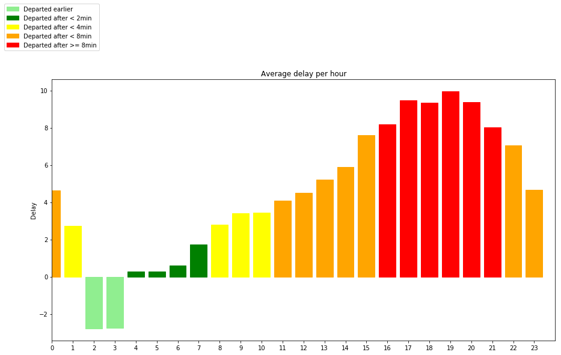

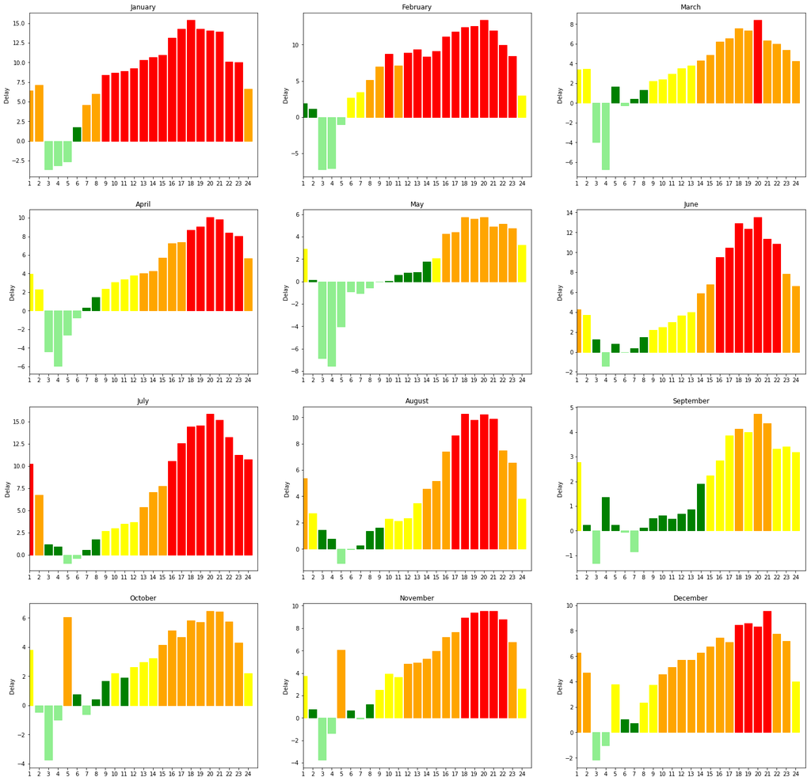

```python
### GLOBAL AGGREGATES
average = df_flight_full_hour.groupBy('flight_full_hour').avg('arrival_delay').orderBy('flight_full_hour')




# # PRINT
average.show()
average_list = average.collect()
pdf_mean_delay_per_hour = pd.DataFrame(data=average_list)
# #Plot
hours=[x for x in range(0,24)]
ratios =[x[1] for x in average_list]

plt.figure(0)
plt.figure(figsize=(15,8))
bars = plt.bar(hours, ratios)
for i in range(0, len(bars)):
    color = 'red'
    if average_list[i][1] < 0:
        color = 'lightgreen'
    elif average_list[i][1] < 2:
        color = 'green'
    elif average_list[i][1] < 4:
        color = 'yellow'
    elif average_list[i][1] < 8:
        color = 'orange'

    bars[i].set_color(color)
patch1 = mpatches.Patch(color='lightgreen', label='Departed earlier')
patch2 = mpatches.Patch(color='green', label='Departed after < 2min')
patch3 = mpatches.Patch(color='yellow', label='Departed after < 4min')
patch4 = mpatches.Patch(color='orange', label='Departed after < 8min')
patch5 = mpatches.Patch(color='red', label='Departed after >= 8min')
plt.xticks([x for x in range(len(statistics.collect()))], [x for x in range(len(statistics.collect()))])
plt.xlim(0, 24)
plt.title('Average delay per hour')
plt.ylabel('Delay')
plt.legend(handles=[patch1, patch2, patch3, patch4, patch5], loc='best', bbox_to_anchor=(-0.4, 0.8, 0.5, 0.5))
plt.show()

# # ### MONTHLY AGGREGATES
flight_hour2 = df_flight_full_hour.groupBy('month', 'flight_full_hour').avg('arrival_delay').orderBy('month', 'flight_full_hour')


# # PLOT

plt.figure(figsize=(25, 25))
a = 4
b = 3
for i in range(12):
    monthly_flights = flight_hour2[df.month == i+1].select('avg(arrival_delay)').collect()
    plt.subplot(a, b, i+1)
    bars = plt.bar([x for x in range(len(monthly_flights))], [x[0] for x in monthly_flights])
    for j in range(0, len(bars)):
        color = 'red'
        if monthly_flights[j][0] < 0:
            color = 'lightgreen'
        elif monthly_flights[j][0] < 2:
            color = 'green'
        elif monthly_flights[j][0] < 4:
            color = 'yellow'
        elif monthly_flights[j][0] < 8:
            color = 'orange'

        bars[j].set_color(color)
    plt.ylabel('Delay')
    plt.title(months_names[i])
    plt.xticks([p for p in range(len(monthly_flights))], [p+1 for p in range(len(monthly_flights))])
    plt.xlim(0, len(monthly_flights))
plt.show()
```

This example shows us that the way representing results are also important.

On the figures below we can observe that between 2 and 3 am planes in average starts few minutes before the time. Again passengers would be the most 'unlucky' if they travel in January as the probability of the delay id the biggest and the average. The best months for travel (for people who want to have the less average delay) are May, September and October (with average <6,5 min).  
Quite surprising is the pick of average delay at 5 am in October, November and December. In November and December we have noticed also this pick on this hour in number of delayed flights.

It might be worth to also analyses the average delay only of delayed flights (with delay over 15 minutes). From above picture we see that maximum average delay it's around 15 min (in January and July), so it's quite confusing that we consider delayed flight when the delay time is >15%, so somebody might have wrong expression that there are not delays. I think that better information for passengers would be ex. "with probability 20% your plane would be late and if it's late it will be in average late 30 minutes".

### Question 4.3

Plot a bar chart to show the percentage of delayed flights over days in a month. Discuss your findings from the figure.

```
+------------+------------------+
|day_of_month|       delay_ratio|
+------------+------------------+
|           1|14.879121138182633|
|           2|15.071630875763267|
|           3|14.854337850816348|
|           4|14.438692082007568|
|           5| 16.99233477612915|
|           6| 16.37503662467038|
|           7|16.580918645839382|
|           8|16.666861970774693|
|           9|18.872040311153185|
|          10|18.175997932476566|
|          11|14.892493705109015|
|          12| 16.77401469842281|
|          13|17.829819540968288|
|          14| 16.84439304746021|
|          15|17.487129327562275|
|          16|17.532135188398975|
|          17|16.995039146074813|
|          18| 17.34179719319478|
|          19|14.538331278063287|
|          20| 17.57137347933295|
+------------+------------------+
only showing top 20 rows
```

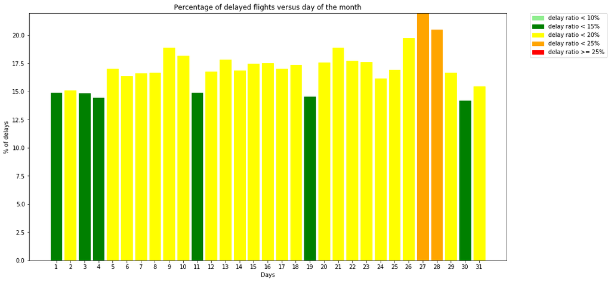

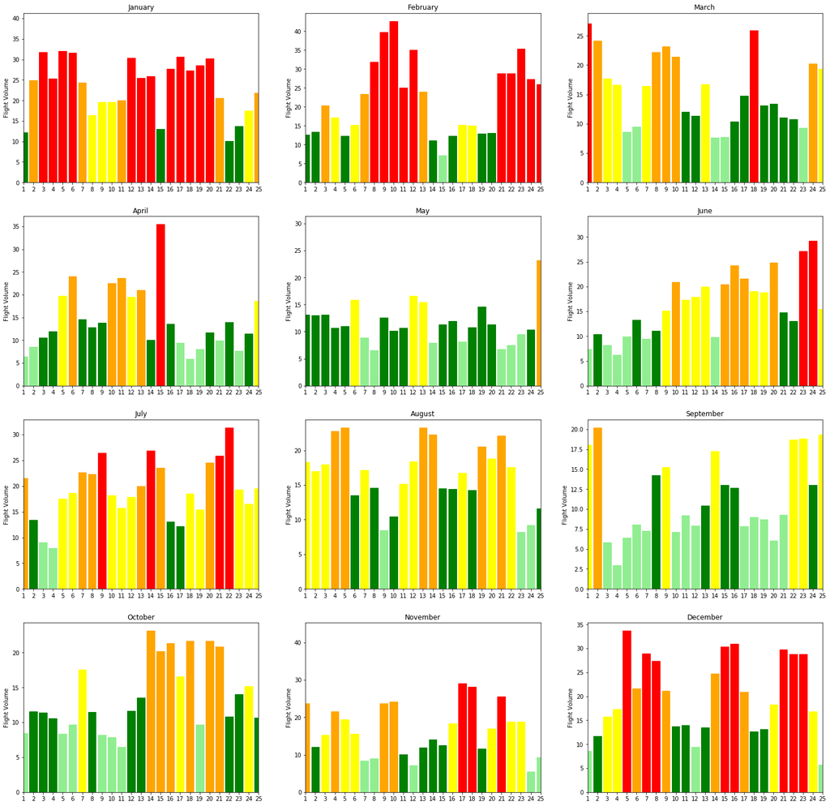

```python
### GLOBAL AGGREGATES
percentage_per_day_month = df_is_delayed.groupBy('day_of_month').agg((100*func.sum('is_delayed')/func.count('*')).alias('delay_ratio')).orderBy('day_of_month')
percentage_list = percentage_per_day_month.collect()
percentage_per_day_month.show()
#Plot
month_days=[x for x in range(1,32)]
volume=[x[1] for x in percentage_list]

plt.figure(0)
plt.figure(figsize=(15,8))
bars= plt.bar(month_days, volume)
for i in range(0, len(bars)):
    color = 'red'
    if percentage_list[i][1] < 10:
        color = 'lightgreen'
    elif percentage_list[i][1] < 15:
        color = 'green'
    elif percentage_list[i][1] < 20:
        color = 'yellow'
    elif percentage_list[i][1] < 25:
        color = 'orange'

    bars[i].set_color(color)

patch1 = mpatches.Patch(color='lightgreen', label='delay ratio < 10%')
patch2 = mpatches.Patch(color='green', label='delay ratio < 15%')
patch3 = mpatches.Patch(color='yellow', label='delay ratio < 20%')
patch4 = mpatches.Patch(color='orange', label='delay ratio < 25%')
patch5 = mpatches.Patch(color='red', label='delay ratio >= 25%')
plt.legend(handles=[patch1, patch2, patch3, patch4, patch5], bbox_to_anchor=(1.05, 1), loc=2, borderaxespad=0.)
plt.margins(0.05, 0)
plt.xticks([x for x in range(1,32)],month_days)
plt.xlabel("Days")
plt.ylabel("% of delays")
plt.title("Percentage of delayed flights versus day of the month")

### MONTHLY AGGREGATES
day_of_month_percentage2= df_is_delayed.groupBy('month', 'day_of_month').agg((100*func.sum('is_delayed')/func.count('*')).alias('delay_ratio')).orderBy('month', 'day_of_month')

# PLOT

plt.figure(figsize=(25, 25))
a = 4
b = 3
for i in range(12):
    monthly_percentage = day_of_month_percentage2[day_of_month_percentage2.month == i+1].select('delay_ratio').collect()
    plt.subplot(a, b, i+1)
    bars = plt.bar([x for x in range(len(monthly_percentage))], [x[0] for x in monthly_percentage])
    for j in range(0, len(bars)):
        color = 'red'
        if monthly_percentage[j][0] < 10:
            color = 'lightgreen'
        elif monthly_percentage[j][0] < 15:
            color = 'green'
        elif monthly_percentage[j][0] < 20:
            color = 'yellow'
        elif monthly_percentage[j][0] < 25:
            color = 'orange'
        bars[j].set_color(color)
    plt.ylabel('Flight Volume')
    plt.title(months_names[i])
    plt.xticks([p for p in range(len(monthly_percentage))], [p+1 for p in range(len(monthly_percentage))])
    plt.xlim(0, len(monthly_flights))
plt.show()
```

When we analyses the first chart (yearly view) we notice that at the beginning of the month percentages of a delay are on of the lowest (below 15%). The same situation happened in 11, 19 and 30 day of the month. However when plot monthly view we see that it vary a lot depending on the month so we can not predict monthly behavior basing on yearly results.  
we have noticed that there is clustering of the delay ratio. It means that if delay ratio is high there is a biggest probability that next day it will be also high and in opposite if the delay ratio is low there is higher probability that the next day it will also be low.

### Question 4.4

Plot a bar chart to show the percentage of delayed flights over days in a week. Discuss your findings from the figure.

```
+------------+------------------+
|day_of_month|       delay_ratio|
+------------+------------------+
|           1|14.879121138182633|
|           2|15.071630875763267|
|           3|14.854337850816348|
|           4|14.438692082007568|
|           5| 16.99233477612915|
|           6| 16.37503662467038|
|           7|16.580918645839382|
|           8|16.666861970774693|
|           9|18.872040311153185|
|          10|18.175997932476566|
|          11|14.892493705109015|
|          12| 16.77401469842281|
|          13|17.829819540968288|
|          14| 16.84439304746021|
|          15|17.487129327562275|
|          16|17.532135188398975|
|          17|16.995039146074813|
|          18| 17.34179719319478|
|          19|14.538331278063287|
|          20| 17.57137347933295|
+------------+------------------+
only showing top 20 rows

+-----+-----------+------------------+
|month|day_of_week|       delay_ratio|
+-----+-----------+------------------+
|    1|          1|22.551970718333546|
|    1|          2| 23.63875228575994|
|    1|          3|30.503718003718003|
|    1|          4|31.639520315017005|
|    1|          5|26.673328455951893|
|    1|          6| 14.19632569453335|
|    1|          7| 22.67048020472678|
|    2|          1|20.363668461470564|
|    2|          2| 20.08523581318856|
|    2|          3|25.049592631951825|
|    2|          4| 26.25972598855036|
|    2|          5|20.787357232106718|
|    2|          6|19.993677263835924|
|    2|          7|17.056787351482832|
|    3|          1|14.497175535253504|
|    3|          2| 16.44405241935484|
|    3|          3|15.164116828929068|
|    3|          4| 16.63006310639126|
|    3|          5|18.451219512195124|
|    3|          6|14.156620639959492|
+-----+-----------+------------------+
only showing top 20 rows
```

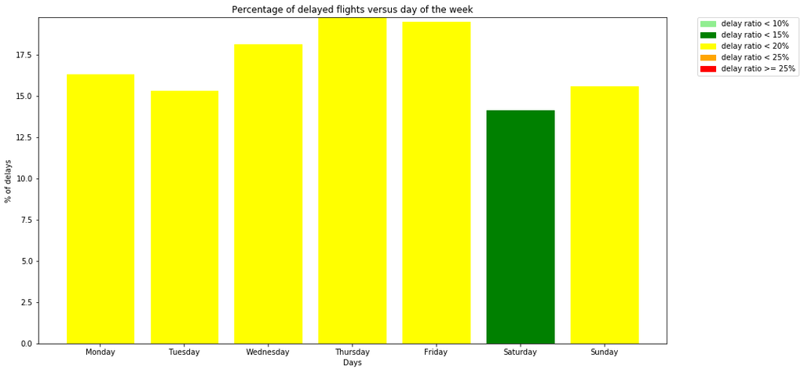

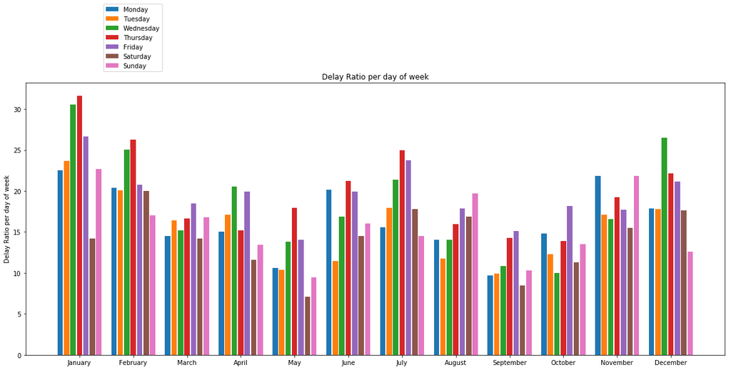

```python
### GLOBAL AGGREGATES
percentage_per_day_week = df_is_delayed.groupBy('day_of_week').agg((100*func.sum('is_delayed')/func.count('*')).alias('delay_ratio')).orderBy('day_of_week')
percentage_list = percentage_per_day_week.collect()
percentage_per_day_month.show()
#Plot
week_days=[x for x in range(1,8)]
volume=[x[1] for x in percentage_list]

plt.figure(0)
plt.figure(figsize=(15,8))
bars= plt.bar(week_days, volume)
plt.xticks([x for x in range(1,8)],days_name)
for i in range(0, len(bars)):
    color = 'red'
    if percentage_list[i][1] < 10:
        color = 'lightgreen'
    elif percentage_list[i][1] < 15:
        color = 'green'
    elif percentage_list[i][1] < 20:
        color = 'yellow'
    elif percentage_list[i][1] < 25:
        color = 'orange'

    bars[i].set_color(color)

patch1 = mpatches.Patch(color='lightgreen', label='delay ratio < 10%')
patch2 = mpatches.Patch(color='green', label='delay ratio < 15%')
patch3 = mpatches.Patch(color='yellow', label='delay ratio < 20%')
patch4 = mpatches.Patch(color='orange', label='delay ratio < 25%')
patch5 = mpatches.Patch(color='red', label='delay ratio >= 25%')
plt.legend(handles=[patch1, patch2, patch3, patch4, patch5], bbox_to_anchor=(1.05, 1), loc=2, borderaxespad=0.)
plt.margins(0.05, 0)
plt.xlabel("Days")
plt.ylabel("% of delays")
plt.title("Percentage of delayed flights versus day of the week")

### MONTHLY AGGREGATES
day_of_month_percentage3= df_is_delayed.groupBy('month', 'day_of_week').agg((100*func.sum('is_delayed')/func.count('*')).alias('delay_ratio')).orderBy('month', 'day_of_week')
day_of_month_percentage3.show()
day_of_week_flights3 = day_of_month_percentage3.collect()


dim = list(range(12))
w = 0.12

fig, ax = plt.subplots(figsize=(20,8))

# # range of 12 as we have 12 months, range of 7 as we have 7 days
for days in range(7):
    values_list = []
    for month in range(12):
        values_list.append(day_of_week_flights3[month*7+days][2])
    plt.bar([x + w*days for x in dim], values_list, w-0.02)

ax.set_ylabel('Delay Ratio per day of week')
ax.set_title("Delay Ratio per day of week")
ax.set_xticks([x + 3 * w for x in dim])
ax.set_xticklabels(months_names)
plt.legend(days_name, loc='best', bbox_to_anchor=(-0.3, 0.8, 0.5, 0.5))
plt.show()
```

The same situation as before - we changed the view to see the average including different numbers of days of week for each month:

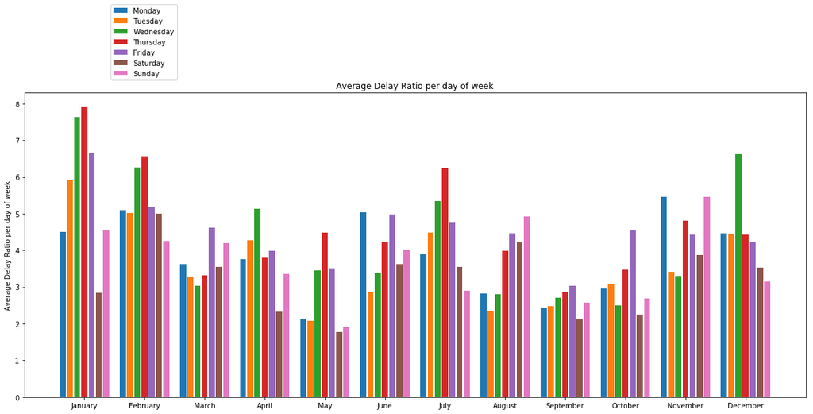

```python
day_of_month_percentage3= df_is_delayed.groupBy('month', 'day_of_week').agg((100*func.sum('is_delayed')/func.count('*')).alias('delay_ratio')).orderBy('month', 'day_of_week')
day_of_week_flights3 = day_of_month_percentage3.collect()


dim = list(range(12))
w = 0.12


fig, ax = plt.subplots(figsize=(20,8))
for days in range(7):
    values_list = []
    for month in range(12):
        count = df.select('month','day_of_week','day_of_month').where((df.month==month+1) & (df.day_of_week==days+1)).distinct().groupBy('day_of_week').count().collect()[0][1]
        values_list.append(day_of_week_flights3[month*7+days][2]/count)
    plt.bar([x + w*days for x in dim], values_list, w-0.02)

ax.set_ylabel('Average Delay Ratio per day of week')
ax.set_title("Average Delay Ratio per day of week")
ax.set_xticks([x + 3 * w for x in dim])
ax.set_xticklabels(months_names)
plt.legend(days_name, loc='best', bbox_to_anchor=(-0.3, 0.8, 0.5, 0.5))
```

In general, during the weekends delay ratio is lower, however for August it seems that it's opposite and on the weekend there is a bigger delay ratio. There is interesting behavior on Mondays of June and November - they have the biggest delay ratio from all week days, when in almost every other months Mondays have one of the lowest (except weekends) delay ratio.

### Question 4.5

Plot a bar chart to show the percentage of delayed flights over months in a year. Discuss your findings from the figure.

We are ready now to draw some observations from our data, even if we have only looked at data coming from a year worth of flights:

- The probability for a flight to be delayed is low at the beginning or at the very end of a given months
- Flights on two first weekdays and on the weekend, are less likely to be delayed
- May and September are very good months for travelling, as the probability of delay is low (remember we're working on US data. Do you think this is also true in France?)

Putting things together, we can have a global picture of the whole year!

```
+-----+------------------+
|month|       delay_ratio|
+-----+------------------+
|    1|24.275411042771097|
|    2| 21.42347669232002|
|    3| 16.04280898979601|
|    4| 16.18879084074633|
|    5|11.835291637643437|
|    6|17.327956106825482|
|    7|19.398696522256476|
|    8|15.460023144145461|
|    9|11.516243057505784|
|   10|13.426382327218834|
|   11| 18.42947782367763|
|   12| 19.56167795019719|
+-----+------------------+
```

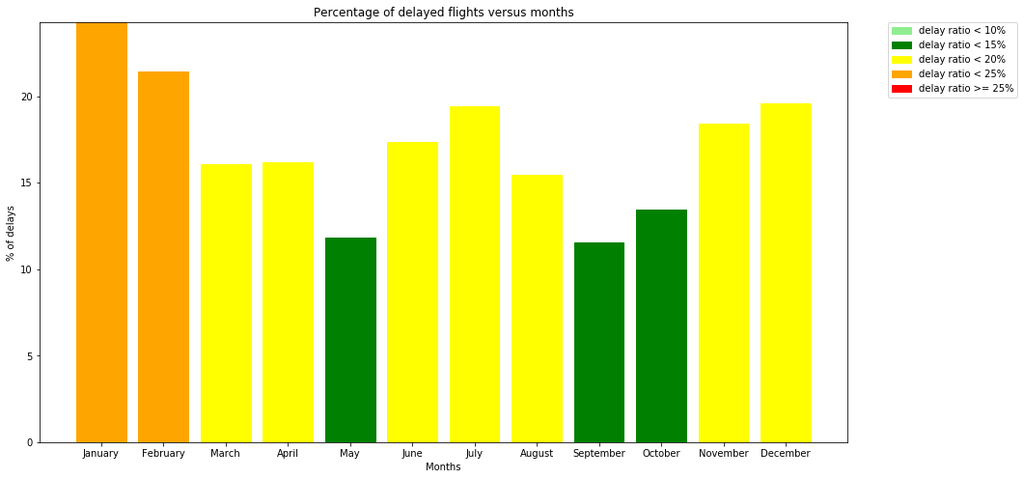

```python
percentage_per_month = df_is_delayed.groupBy('month').agg((100*func.sum('is_delayed')/func.count('*')).alias('delay_ratio')).orderBy('month')
percentage_list = percentage_per_month.collect()
percentage_per_month.show()
#Plot
months=[x for x in range(1,13)]
volume=[x[1] for x in percentage_list]

plt.figure(0)
plt.figure(figsize=(15,8))
bars= plt.bar(months, volume)
plt.xticks([x for x in range(1,13)],months_names)
for i in range(0, len(bars)):
    color = 'red'
    if percentage_list[i][1] < 10:
        color = 'lightgreen'
    elif percentage_list[i][1] < 15:
        color = 'green'
    elif percentage_list[i][1] < 20:
        color = 'yellow'
    elif percentage_list[i][1] < 25:
        color = 'orange'

    bars[i].set_color(color)

patch1 = mpatches.Patch(color='lightgreen', label='delay ratio < 10%')
patch2 = mpatches.Patch(color='green', label='delay ratio < 15%')
patch3 = mpatches.Patch(color='yellow', label='delay ratio < 20%')
patch4 = mpatches.Patch(color='orange', label='delay ratio < 25%')
patch5 = mpatches.Patch(color='red', label='delay ratio >= 25%')
plt.legend(handles=[patch1, patch2, patch3, patch4, patch5], bbox_to_anchor=(1.05, 1), loc=2, borderaxespad=0.)
plt.margins(0.05, 0)
plt.xlabel("Months")
plt.ylabel("% of delays")
plt.title("Percentage of delayed flights versus months")

plt.show()
```

On the beginning of the year there were the biggest delay ratio and the lowest were in May, September and October.  
As we have data only from one year it's hard to say if it would have happened every year as it might be caused by extremal weather conditions or e.x changes in airports low. We are very suspicious about this results for January and February as in the same time there were months with the lowest flight volume. It might be also related to year closing and some factors related to do (ex. additional administration).

```python
df_with_delay = df.withColumn('is_delay', func.when(df["arrival_delay"] >= 15, 1).otherwise(0))
statistic_day = df_with_delay.groupBy(['year','month', 'day_of_month', 'day_of_week'])\
    .agg((func.sum('is_delay')/func.count('*')).alias('delay_ratio'))

# assume that we do statistic on year 1994
statistic_day = statistic_day\
    .orderBy('year', 'month', 'day_of_month', 'day_of_week')
pdf = pd.DataFrame(data=statistic_day.collect())
```

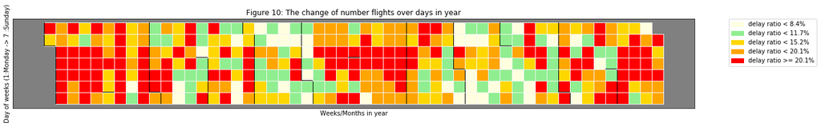

```python
fig = plt.figure(figsize=(20,10))
ax = fig.add_subplot(1,1,1)
plt.xlabel("Weeks/Months in year")
plt.ylabel("Day of weeks (1:Monday -> 7 :Sunday)")
plt.title('Figure 10: The change of number flights over days in year')

rec_size = 0.3
from matplotlib.patches import Rectangle
import datetime
num_days = len(pdf[0])
ax.patch.set_facecolor('gray')
ax.set_aspect('equal', 'box')
ax.xaxis.set_major_locator(plt.NullLocator())
ax.yaxis.set_major_locator(plt.NullLocator())

for i in range(0, num_days):
    # extract information from the result
    year = pdf[0][i]
    month = pdf[1][i]
    day_of_month = pdf[2][i]
    day_of_week = pdf[3][i]
    day_of_year= datetime.date(year=year, month=month, day=day_of_month).timetuple()
    week_of_year = datetime.date(year=year, month=month, day=day_of_month).isocalendar()[1]

    # dealing with the week of the previous year
    if week_of_year == 52 and month == 1:
        week_of_year = 0

    # the coordinate of a day in graph
    X = week_of_year*rec_size
    Y = day_of_week*rec_size

    # use different colors to show the delay ratio
    color = 'white'
    if pdf[4][i] <= 0.084:
        color = 'lightyellow'
    elif pdf[4][i] <= 0.117:
        color = 'lightgreen'
    elif pdf[4][i] <= 0.152:
        color = 'gold'
    elif pdf[4][i] <= 0.201:
        color = 'orange'
    else:
        color = 'red'
    rect = plt.Rectangle((X - rec_size/2.0, Y - rec_size/2.0), rec_size, rec_size,
                      alpha=1, facecolor=color, edgecolor='whitesmoke')

    ax.add_patch(rect)

    # drawing boders to separate months
    if day_of_month <= 7:
        rect2 = plt.Rectangle((X -rec_size/2.0, Y - rec_size/2.0), 0.01, rec_size,
                      alpha=1, facecolor='black')
        ax.add_patch(rect2)
    if day_of_month == 1:
        rect2 = plt.Rectangle((X - rec_size/2.0, Y - rec_size/2.0), rec_size, 0.01,
                      alpha=1, facecolor='black')
        ax.add_patch(rect2)
ax.autoscale_view()

patch1 = mpatches.Patch(color='lightyellow', label='delay ratio < 8.4%')
patch2 = mpatches.Patch(color='lightgreen', label='delay ratio < 11.7%')
patch3 = mpatches.Patch(color='gold', label='delay ratio < 15.2%')
patch4 = mpatches.Patch(color='orange', label='delay ratio < 20.1%')
patch5 = mpatches.Patch(color='red', label='delay ratio >= 20.1%')

plt.legend(handles=[patch1, patch2, patch3, patch4, patch5], bbox_to_anchor=(1.05, 1), loc=2, borderaxespad=0.)

plt.show()
```

On the above figure we can see a clustering of delay ratio>20.

### Question 4.6

What is the delay probability for the top 20 busiest airports? By drawing the flight volume of each airport and the associated delay probability in a single plot, we can observe the relationship between airports, number of flights and the delay.

HINT

Function `.isin()` helps checking whether a value in column belongs to a list.

SUGGESTION

You can try with different chart type to have a better visualization.

```
Delay probability and flight volume for top busiest airports:
+-------+------+-------------------+
|airport| count|        delay_ratio|
+-------+------+-------------------+
|    MCO|153720|0.17871454592766067|
|    DCA|176115|0.16124691252874543|
|    PHL|186897|0.20326168959373345|
|    LAS|189920|0.17209877843302443|
|    BOS|199696|0.21722017466549154|
|    LGA|203362| 0.1854427080772219|
|    IAH|208591|0.16711171622936752|
|    EWR|233991| 0.2611980802680445|
|    SFO|235478|  0.184632959342274|
|    MSP|247980|0.13999112831679975|
|    CLT|259712|0.18741529078363725|
|    PIT|262939|0.19441011032977232|
|    DTW|276272|0.14818729368158917|
|    PHX|280560|0.16685201026518393|
|    DEN|285526| 0.1950330267646379|
|    STL|304409|0.16954820652477423|
|    LAX|306453|0.18532695062538138|
|    ATL|443074|0.20877099536420554|
|    DFW|516523|0.20272088561399976|
|    ORD|561461| 0.1556564035614228|
+-------+------+-------------------+
```

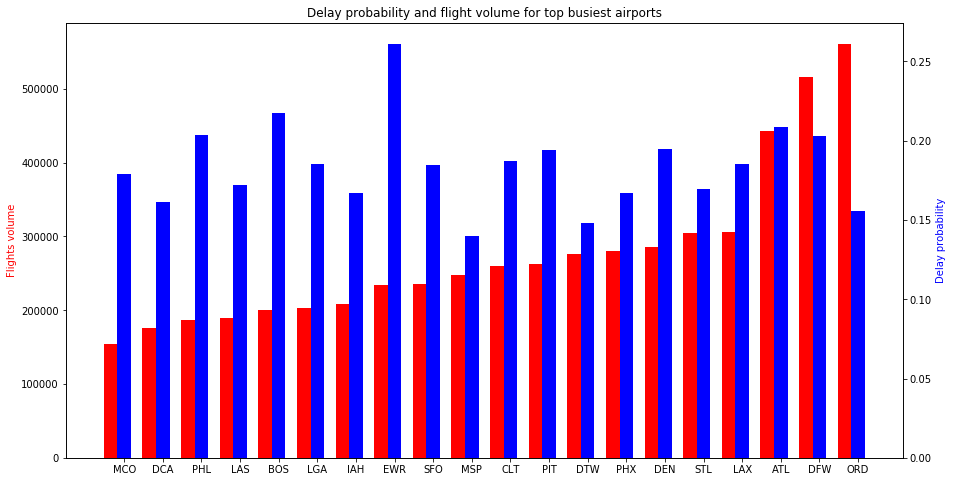

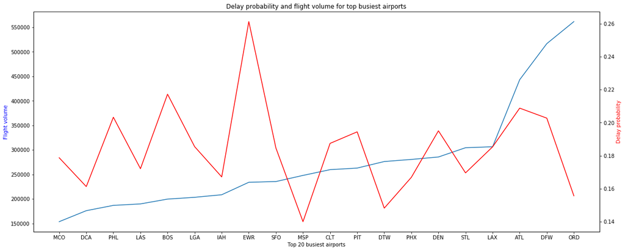

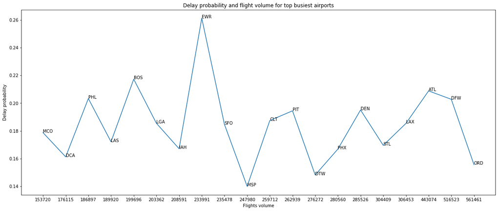

```python
df_airport = df.withColumn('airport', df.src_airport).union(df.withColumn('airport', df.dest_airport))
top_busiest_airport = df_airport.groupBy('airport').count().orderBy('count', ascending=False)

top_20 = top_busiest_airport.take(20)
top_20 = [x[0] for x in top_20]

# QUERY
# filter the df (with airport column) and add the is_delay column as we did also in the previous questions
df_with_delay = df_airport.filter(df_airport.airport.isin(top_20)).withColumn('is_delayed', func.when((df["arrival_delay"] >= 15), 1).otherwise(0))
# then group by airport, and for each airport, compute the delay ratio
statistic_day = df_with_delay.groupBy('airport').agg((func.sum('is_delayed')/func.count('*')).alias('delay_ratio')).orderBy('delay_ratio')


# PRINT & COLLECT
print('Delay probability and flight volume for top busiest airports:')
data = top_busiest_airport.join(statistic_day, on='airport').select('*').orderBy('count')
data.show()
data = data.collect()


# PLOT (bar chart)
fig = plt.figure(figsize=(15,8))
ax = fig.add_subplot(111)
ax.bar([x for x in range(len(data))], [x[1] for x in data], 0.35, color='r')
ax.set_ylabel('Flights volume', color='r')
ax2 = ax.twinx()
ax2.bar([x+0.35 for x in range(len(data))], [x[2] for x in data], 0.35, color='b')
ax2.set_ylabel('Delay probability', color='b')
plt.xticks([x+0.35 for x in range(len(data))], [x[0] for x in data])
plt.title('Delay probability and flight volume for top busiest airports')
plt.show()


# PLOT (line chart with x=airport, y1=flight volume, y2=delay)
fig = plt.figure(figsize=(20,8))
ax = fig.add_subplot(111)
ax.set_title('Delay probability and flight volume for top busiest airports')
ax.plot([x for x in range(len(data))], [x[1] for x in data])
ax.set_xlabel('Top 20 busiest airports')
ax.set_ylabel('Flight volume', color='b')
ax2 = ax.twinx()
ax2.plot([x for x in range(len(data))], [x[2] for x in data], c='r')
ax2.set_ylabel('Delay probability', color='r')
plt.xticks([x for x in range(len(data))], [x[0] for x in data])
plt.show()


# PLOT (line chart with x=flight volume and y=delay prob)
plt.figure(figsize=(20,8))
plt.plot([x for x in range(len(data))], [x[2] for x in data])
plt.xticks([x for x in range(len(data))], [x[1] for x in data])
for x in range(len(data)):
    plt.annotate('%s' % data[x][0], xy=(x, data[x][2]))
plt.title('Delay probability and flight volume for top busiest airports')
plt.ylabel('Delay probability')
plt.xlabel('Flights volume')
plt.show()
```

There is no correlation between the "business" of the airport and the delay probability. maybe we could see some pattern plotting more airports not only top 20.  
Interesting is EWR airport - it's an outliner with its 26% chance of delay.

### Question 4.7

What is the percentage of delayed flights which belong to one of the top 20 busiest carriers? Comment the figure!

SUGGESTION

You can try with different chart type to have a better visualization.

```
Delay probability and flight volume for top busiest carriers:
+-------+-------+-------------------+
|carrier|  count|        delay_ratio|
+-------+-------+-------------------+
|     AS| 234950| 0.1596424771227921|
|     HP| 355702|0.18625141269939444|
|     TW| 516410|0.18212273193780135|
|     NW| 965596| 0.1294806523639286|
|     CO| 969668| 0.1955576547849367|
|     WN|1130852|0.12829795587751536|
|     UA|1277500| 0.1686528375733855|
|     AA|1444554| 0.1752444006939166|
|     US|1715812|0.18422298014001534|
|     DL|1749052|0.18328443065157582|
+-------+-------+-------------------+
```

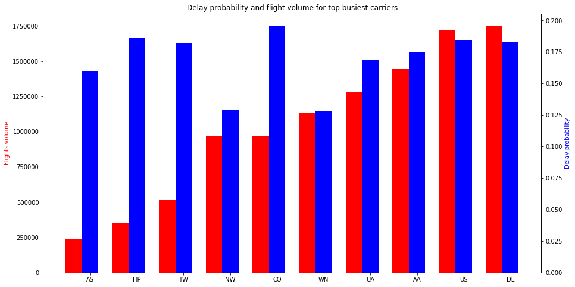

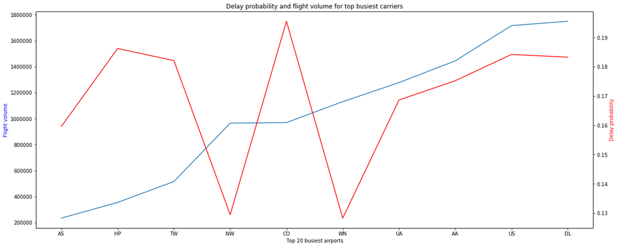

```
Text(0.5,0,'Flights volume')
```

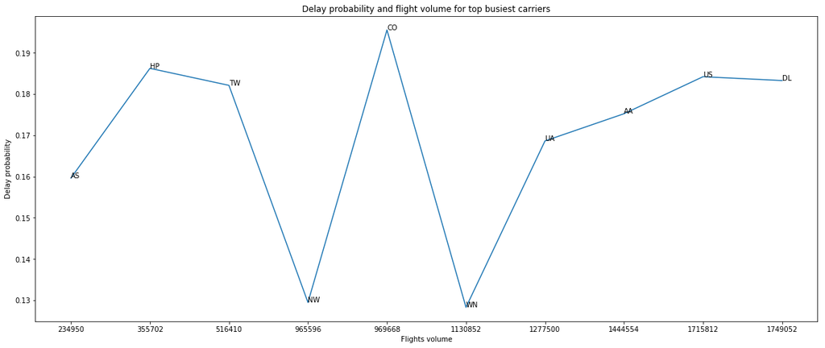

```python
top_busiest_carriers = df_airport.groupBy('carrier').count().orderBy('count', ascending=False)

top_20 = top_busiest_carriers.take(20)
top_20 = [x[0] for x in top_20]

# QUERY
# filter the df (with airport column) and add the is_delay column as we did also in the previous questions
df_with_delay = df.filter(df.carrier.isin(top_20)).withColumn('is_delayed', func.when((df["arrival_delay"] >= 15), 1).otherwise(0))
# then group by airport, and for each airport, compute the delay ratio
statistic_day = df_with_delay.groupBy('carrier').agg((func.sum('is_delayed')/func.count('*')).alias('delay_ratio')).orderBy('delay_ratio')


# PRINT & COLLECT
print('Delay probability and flight volume for top busiest carriers:')
data = top_busiest_carriers.join(statistic_day, on='carrier').select('*').orderBy('count')
data.show()
data = data.collect()


# PLOT (bar chart)
fig = plt.figure(figsize=(15,8))
ax = fig.add_subplot(111)
ax.bar([x for x in range(len(data))], [x[1] for x in data], 0.35, color='r')
ax.set_ylabel('Flights volume', color='r')
ax2 = ax.twinx()
ax2.bar([x+0.35 for x in range(len(data))], [x[2] for x in data], 0.35, color='b')
ax2.set_ylabel('Delay probability', color='b')
plt.xticks([x+0.35 for x in range(len(data))], [x[0] for x in data])
plt.title('Delay probability and flight volume for top busiest carriers')
plt.show()


# PLOT (line chart with x=airport, y1=flight volume, y2=delay)
fig = plt.figure(figsize=(20,8))
ax = fig.add_subplot(111)
ax.set_title('Delay probability and flight volume for top busiest carriers')
ax.plot([x for x in range(len(data))], [x[1] for x in data])
ax.set_xlabel('Top 20 busiest airports')
ax.set_ylabel('Flight volume', color='b')
ax2 = ax.twinx()
ax2.plot([x for x in range(len(data))], [x[2] for x in data], c='r')
ax2.set_ylabel('Delay probability', color='r')
plt.xticks([x for x in range(len(data))], [x[0] for x in data])
plt.show()


# PLOT (line chart with x=flight volume and y=delay prob)
plt.figure(figsize=(20,8))
plt.plot([x for x in range(len(data))], [x[2] for x in data])
plt.xticks([x for x in range(len(data))], [x[1] for x in data])
for x in range(len(data)):
    plt.annotate('%s' % data[x][0], xy=(x, data[x][2]))
plt.title('Delay probability and flight volume for top busiest carriers')
plt.ylabel('Delay probability')
plt.xlabel('Flights volume')
```

There is no visible correlation between the "business" carriers and the delay probability.  
There are only few carriers to investigate so there is hard to make the conclusions. We might put a theory (only theory as it’s too less data) that maybe there is a pattern - that the small carriers (below 600000 flights, and the biggest carriers (above 120000 flights) have higher delay probabilities that medium ones (and in this interpretation CO would be an outliner). Still it is only a theory which might be investigated by checking if CO is anyhow different from other carriers (example has long distance flights)

## Addition (bonus) questions

### Additional data

In the HDFS file system you have used for running the Notebook, you will notice that there are several other years available (in addition to 1994).

There are some other datasets that related to this use case:

- Airport IATA Codes to City names and Coordinates mapping: http://stat-computing.org/dataexpo/2009/airports.csv
- Carrier codes to Full name mapping: http://stat-computing.org/dataexpo/2009/carriers.csv
- Information about individual planes: http://stat-computing.org/dataexpo/2009/plane-data.csv
- Weather information: http://www.wunderground.com/weather/api/. You can subscribe for free to the developers' API and obtain (at a limited rate) historical weather information in many different formats. Also, to get an idea of the kind of information is available, you can use this link: http://www.wunderground.com/history/

### Question 5.1

Which airports are present in the dataset only as destination airport? Which airport is present only as source airport in the dataset?

### Question 5.2

Which airports have biggest delay probability ? Which cities have largest delay duration in average ?

### Question 5.3

Is there any relationship between weather condition and the delay of flights in 1994 ?